# Analysis

Alexa Varah

2024-01-19

# 1. Rationale / intro

This script analyses model output from model runs simulating ‘current’ conditions (also called the ‘original’ model runs) and from the ‘worst case’ model runs.

## 1.1. Current conditions

For *‘current’ conditions*, models were run as follows:  
- Weed density estimation simulations were initialised with the initial density distribution for which each strategy was designed (based on observed weed densities in the field in 2014).  
- ECOMOD output was weighted by the initial density distribution for which each strategy was designed.

We use the weighted values for gross profit and yield, and compare outcomes across the three scenarios (BAU, CWW and MIT).  
Opportunity costs are calculated as follows (productivity costs are calculated in the same way):

Opportunity costs~(BAU, current density – MIT, current density)~ *vs* Opportunity costs~(BAU, very high density – MIT, very high density)~

We investigate which scenario is better for profits and yield, and whether there is a situation where we should act preemptively. In other words, is it ever better for profits or wheat production to switch preemptively to MIT, or is it better to continue with BAU in the knowledge that weed density will get worse?

## 1.2. Worst case conditions

In this analysis, under current conditions, we show that it’s only worth switching to MIT at low densities and low resistance.  
**LD-LR** For low density and low resistance it is already financially viable to switch.  
**LD-HR** For low density and high resistance the opportunity costs are mostly small to negligible, so might it become worth switching under higher densities?  
**HD-HR** For high density and resistance it’s not worth switching to MIT. **Does it ever become worth switching?**

This suggests that in LD-HR and HD-HR fields farmers are unlikely to switch to MIT strategies. However, our previous work shows that repeated use of selective herbicides (as found in BAU strategies) drives high resistance and high density. So, in a future where resistance is potentially very high everywhere, does BAU drive up densities more than MIT, such that it eventually becomes worth switching to MIT? We model this by assuming high density and very high resistance as a starting point and seeing what happens to black-grass density under various sequences of BAU and MIT. (N.B. We don’t assert that it is a situation that’s ever likely to happen: we’re just exploring it as a ‘worst case’ situation).

For *‘worst case’ conditions*, models were therefore run as follows:  
- Weed density estimation simulations were all initialised with very high density distribution (i.e., we initiliased model runs with very high density distributions for all strategies).  
- We only used ECOMOD output from models run with very high initial density.

The density estimation models don’t allow resistance to evolve, but this is a moot point here as we assume resistance has already evolved (so that it’s high everywhere) and we run forward from that point. No further evolution of resistance is possible (we have already set it to ‘high’) and resistance doesn’t disappear as there are no fitness costs. We start model runs with a very high density distribution (A 0.1, L 0.1, M 0.2, H 0.3, VH 0.3). This of course leaves space for further grid cells to switch into higher densities. We then simulate what will happen to black-grass densities under these conditions of high resistance and very high initial density distribution when we run the switching sequences outlined below.

For the worst case analysis, we investigate gross profit and yield outcomes of switching from BAU to MIT immediately, after one 6-year BAU rotation, or after two 6-year BAU rotations, as follows:  
- (a) BAU -> BAU -> BAU (never switch to MIT)  
- (b) BAU -> BAU -> MIT (switch to MIT after two 6-year BAU rotations)  
- (c) BAU -> MIT -> MIT (switch to MIT after one 6-year BAU rotation)  
- (d) MIT -> MIT -> MIT (switch to MIT immediately)

We investigate whether, at very high black-grass density, it is ever better (for either profits or yield) to be doing MIT strategies. And if so, when?

We don’t include CWW in the worst case analysis as we show in the analysis using ‘current’ densities that CWW is nether financially better than BAU nor does it control black-grass populations.

# 2. Set up

## 2.1. Load packages

```r
rm(list=ls())
library(tidyverse) # for data manipulation; includes dplyr, ggplot2 & more
library(patchwork) # for panel plots
#R.Version() #"R version 4.3.2 (2023-10-31)"
```

## 2.2. Load functions

This counts complete observations

```r
nobs <- function(x) length(x[!is.na(x)])
```

## 2.3. Load data

```r
# Density data - initialised with current densities
simden_curr <- readRDS("../output/simden_orig_tidy.rds") %>%
  dplyr::mutate(
    scenario = factor(scenario, levels = c("BAU", "MIT", "CWW")), # specify order of levels
    region = factor(region, levels = c("n", "c", "e")), # specify order of levels
    soiltype = factor(soiltype, levels = c("h", "m", "l")), # specify order of levels
    initcondit = paste(region, soiltype, initdenres, sep = "_")
  )

# Density data - initialised with worst case densities
simden_worstcase <- readRDS("../output/simden_worstcase_tidy.rds") %>%
  dplyr::mutate(
    scenario = factor(scenario, levels = c("BAU", "MIT", "CWW")), # specify order of levels
    rotn_seq = factor(rotn_seq, levels = c("BBB", "BBM", "BMM", "MMM")), # specify order of levels
    region = factor(region, levels = c("n", "c", "e")), # specify order of levels
    soiltype = factor(soiltype, levels = c("h", "m", "l")), # specify order of levels
    initcondit = paste(region, soiltype, initdenres, sep = "_")
  )

# Weighted economic values - current densities
weighted_curr <- readRDS("../output/weighted-gp-yield-oc_orig.rds") %>%
  dplyr::mutate(
    scenario = factor(scenario, levels=c("BAU", "MIT", "CWW")),
    region = factor(region, levels = c("n", "c","e")),
    soiltype = factor(soiltype, levels = c("h", "m","l")),
    initcondit = factor(initcondit)
  )

# Weighted economic values - worst case densities
weighted_worstcase <- readRDS("../output/weighted-gp-yield-oc_worstcase.rds") %>%
  dplyr::mutate(
    Rob_initDR = factor(Rob_initDR),
    rotn_seq = factor(rotn_seq),
    scenario = factor(scenario, levels=c("BAU", "MIT", "CWW")),
    region = factor(region, levels = c("n", "c","e")),
    soiltype = factor(soiltype, levels = c("h", "m","l")),
  )

# Cereal areas
cereal <- read.csv("../output/cerealarea_by_localauthority_and_denres_3DR_2021.csv", header = TRUE) %>%
  dplyr::mutate(initDR = as.factor(initDR),
                initDR = fct_recode(initDR,
                                    "LD-LR" = "LDLR",
                                    "LD-HR" = "LDHR",
                                    "HD-HR" = "HDHR")
                ) %>%
  mutate(region = recode(region,
                         north = "n", # old, new
                         central = "c",
                         east = "e"
                         )
         )

# Details of management strategies
strats <- readRDS("../data/rotation_data.rds")
```

## 2.4. Data processing

### 2.4.1. Economic data

Collapse the economic data back to the three initial density-resistance levels presented to farmers (LD-LR, LD-HR, HD-HR).

```r
# At current densities
econ_curr <- weighted_curr %>%

  # Collapse initial density and resistance states to original three
  dplyr::mutate(
    initDR = forcats::fct_recode(initdenres, # collapse categories
                                  "LD-LR" = "MD-LR", # new, old
                                  "LD-HR" = "MD-HR",
                                  "HD-HR" = "VD-HR"),
    initDR = factor(initDR, levels = c("LD-LR", "LD-HR", "HD-HR"))
                ) %>%

  # Calculate mean values across imputations for each year of each strategy
  group_by(scenario, year, initDR, region, soiltype) %>%
  dplyr::mutate(
    gpmean = mean(wtd_gp),
    ocmean = mean(wtd_opp_cost),
    wwmean = mean(ww_yield),
    pcmean = mean(wtd_prod_cost),
    cylmean = mean(wtd_cyl),
    outputmean = mean(wtd_output),
    potoutmean = mean(potential_output),
    fuelmean = mean(wtd_fuelcost),
    labmean = mean(wtd_labcost),
    opsmean = mean(wtd_opscost)
    ) %>%
  ungroup() %>%
  distinct(scenario, year, initDR, region, soiltype, .keep_all = TRUE) %>%
  dplyr::select(ID, strategy, scenario, region, soiltype, initDR, initcondit, year, crop,
                gpmean:opsmean, fertcost:other) %>%
  dplyr::mutate(scenario = factor(scenario, levels = c("BAU", "MIT", "CWW")))


# At worst case densities
econ_wc <- weighted_worstcase %>%

  # Collapse initial density and resistance states to original three
  dplyr::mutate(
    initDR = forcats::fct_recode(initdenres, # collapse categories
                                  "LD-LR" = "MD-LR", # new, old
                                  "LD-HR" = "MD-HR",
                                  "HD-HR" = "VD-HR"),
    initDR = factor(initDR, levels = c("LD-LR", "LD-HR", "HD-HR"))
                ) %>%

  # Calculate mean values across imputations for each year of each strategy
  group_by(rotn_seq, year, initDR, region, soiltype) %>%
  dplyr::mutate(
    gpmean = mean(wtd_gp),
    ocmean = mean(wtd_opp_cost),
    wwmean = mean(ww_yield),
    pcmean = mean(wtd_prod_cost),
    outputmean = mean(wtd_output),
    fuelmean = mean(wtd_fuelcost),
    labmean = mean(wtd_labcost),
    opsmean = mean(wtd_opscost)
    ) %>%
  ungroup() %>%
  distinct(rotn_seq, year, initDR, region, soiltype, .keep_all = TRUE) %>%
  dplyr::select(ID, strategy, rotn_seq, scenario, region, soiltype, initDR,
                initcondit, year, rotation, crop, gpmean:opsmean) %>%
  dplyr::mutate(
    scenario = factor(scenario, levels = c("BAU", "MIT", "CWW")),
    rotn_seq = factor(rotn_seq, levels = c("BBB", "BBM", "BMM", "MMM"))
    )
```

### 2.4.2. Density data

To estimate the black-grass density resulting from the different strategies (crop rotations), we ran 37 imputations per strategy. This produced 37 simulated density distributions at each yearly time step for each strategy. Here, we calculate the mean proportion high and very high density squares in a field by averaging across imputations. We collapse the data back to the three initial density-resistance levels presented to farmers (LD-LR, LD-HR, HD-HR).

In the paper we present the mean proportion of a field with economically-damaging (i.e., high and very high density) black-grass.

**Rationale for presenting proportion of field with economically-damaging black-grass** We calculate mean proportions of the two highest density states per field because they are economically important - they affect wheat yield and thus also gross profit. The lower density states are not economically important as they have zero yield penalty on winter wheat crops (Varah et al., 2020).  
An alternative would be to use the mean density state across the whole field. We discounted this approach because a mean state of 3 (high), for example, could signify that the whole field had a high density of black-grass; alternatively, it could mean that part of the field had absent (0), low (1) or medium (2) density black-grass and part of the field had very high (4) densities of black-grass. These two situations have different implications for field-scale wheat yield and profit.

```r
# Process simulated density data initialised with current densities
prop_hvh <- simden_curr %>%

  # Sum the proportions of high and very high density black-grass
  rowwise() %>%
  dplyr::mutate(hvh = sum(c_across(h:v), na.rm = T)) %>%  # new category: h & vh
  ungroup() %>%

  # Collapse initial density and resistance states to original three
  dplyr::mutate(
    initDR = forcats::fct_recode(initdenres, # collapse categories
                                  "LD-LR" = "MD-LR", # new, old
                                  "LD-HR" = "MD-HR",
                                  "HD-HR" = "VD-HR"),
    initDR = factor(initDR, levels = c("LD-LR", "LD-HR", "HD-HR"))
                ) %>%

  # Calculate mean hvh across imputations for each year of each strategy
  group_by(scenario, year, initDR, region, soiltype) %>%
  dplyr::mutate(
    hvh_mean = mean(hvh),
    hvh_sd = sd(hvh)) %>%
  ungroup() %>%
  distinct(scenario, year, initDR, region, soiltype, .keep_all = TRUE) %>%
  dplyr::select(ID, strategy, scenario, region, soiltype, initDR, year, hvh_mean, hvh_sd) %>%
  dplyr::arrange(scenario, initDR, region, soiltype)

# Process simulated density data initialised with worst case densities
prop_hvh_wc <- simden_worstcase %>%

  # Sum the proportions of high and very high density black-grass
  rowwise() %>%
  dplyr::mutate(hvh = sum(c_across(h:v), na.rm = T)) %>%  # new category: h & vh
  ungroup() %>%

  # Collapse initial density and resistance states to original three
  dplyr::mutate(
    initDR = forcats::fct_recode(initdenres, # collapse categories
                                  "LD-LR" = "MD-LR", # new, old
                                  "LD-HR" = "MD-HR",
                                  "HD-HR" = "VD-HR"),
    initDR = factor(initDR, levels = c("LD-LR", "LD-HR", "HD-HR"))
                ) %>%

  # Calculate mean hvh across imputations for each year of each strategy
  group_by(rotn_seq, year, initDR, region, soiltype) %>%
  dplyr::mutate(
    hvh_mean = mean(hvh),
    hvh_sd = sd(hvh)) %>%
  ungroup() %>%
  distinct(rotn_seq, year, initDR, region, soiltype, .keep_all = TRUE) %>%
  dplyr::select(ID, strategy, rotn_seq, scenario, region, soiltype, initDR, year, hvh_mean, hvh_sd) %>%
  dplyr::arrange(rotn_seq, initDR, region, soiltype)

# Clear up
rm(simden_curr, simden_worstcase)
```

### 2.4.3. Cereal area data

```r
# Calculate cereal area of each density state (-> used to scale up values for Table 2).
cereal_ds <- cereal %>%
  dplyr::group_by(initDR) %>%
  dplyr::summarise(cereal_area = sum(cereal_area_in_denres_state)) %>%
  dplyr::mutate(region="all") %>%
  dplyr::relocate(region)

# Calculate cereal area of each region (-> used to scale up values for Table S7).
cereal_region <- cereal %>%
  dplyr::group_by(region) %>%
  dplyr::summarise(cereal_area = sum(cereal_area_in_denres_state)) %>%
  dplyr::mutate(initDR="all") %>%
  dplyr::relocate(region, initDR)

# Calculate cereal area of each density state within each region (-> used to scale up values for Table S7).
cereal_ds_region <- cereal %>%
  dplyr::group_by(region, initDR) %>%
  dplyr::summarise(cereal_area = sum(cereal_area_in_denres_state))
#Join data sets.
cereal_for_scaling <- rbind(cereal_region, cereal_ds, cereal_ds_region) %>%
  dplyr::mutate(ID = paste(region, initDR, sep = "_"))
```

### 2.4.4. Management strategies

Remove medium soils because the strategies for heavy soils are simply repeated for medium soils.

```r
strats <- strats %>%
  dplyr::filter(initdenres %in% c("LD-LR", "LD-HR", "HD-HR") & !soil_type == "medium") %>%
  dplyr::mutate(
    initDR3 = factor(initDR3, levels = c("LD-LR", "LD-HR", "HD-HR")),
    region = factor(region, levels = c("north", "central", "east")),
    soil_type = factor(soil_type, levels = c("heavy", "medium", "light"))) %>%
  dplyr::arrange(scenario, region, initdenres, soil_type)
```

# 3. Main Analysis

## 3.1. Table 1 - Effect of scenario on weed density, profit and ww yield

### 3.1.1. Table 1 (a)

#### Mean final density

Mean proportion of field with high and/or very high black-grass density at year 6.

```r
tbl1_a_yr6 <- prop_hvh %>%
  dplyr::filter(year==6) %>%
  group_by(scenario) %>%
  dplyr::mutate(
    hvh_yr6 = mean(hvh_mean),
    hvh_yr6_min = min(hvh_mean),
    hvh_yr6_max = max(hvh_mean)
    ) %>%
  ungroup() %>%
  distinct(scenario, .keep_all = TRUE) %>%
  dplyr::select(scenario, hvh_yr6, hvh_yr6_min, hvh_yr6_max) %>%
  dplyr::arrange(scenario) %>%
  mutate(across(hvh_yr6:hvh_yr6_max, ~round(.x, 2)))

tbl1_a_yr6
```

```
## # A tibble: 3 × 4
##   scenario hvh_yr6 hvh_yr6_min hvh_yr6_max
##   <fct>      <dbl>       <dbl>       <dbl>
## 1 BAU         0.75        0.22        0.95
## 2 MIT         0.24        0.01        0.62
## 3 CWW         0.49        0.04        0.75
```

#### Mean annual density

Mean proportion of field with high and/or very high black-grass density annually. Calculate mean value for each strategy first, then summarise across scenarios. In this way, the min and max values will show the range across region, soil type and initial den-res, rather than showing year-to-year variation.

```r
# find rotation mean first
tbl1_a_ann <- prop_hvh %>%
  dplyr::group_by(scenario, region, soiltype, initDR) %>%
  dplyr::summarize(
    mean_hvh = mean(hvh_mean)
    ) %>%
  ungroup() %>%
  # then find scenario means
  dplyr::group_by(scenario) %>%
  dplyr::summarize(
    hvh_ann = mean(mean_hvh),
    hvh_ann_min = min(mean_hvh),
    hvh_ann_max = max(mean_hvh)
    ) %>%
  mutate(across(hvh_ann:hvh_ann_max, ~round(.x, 2)))
tbl1_a_ann
```

```
## # A tibble: 3 × 4
##   scenario hvh_ann hvh_ann_min hvh_ann_max
##   <fct>      <dbl>       <dbl>       <dbl>
## 1 BAU         0.5         0.12        0.74
## 2 MIT         0.2         0.09        0.45
## 3 CWW         0.38        0.03        0.67
```

### 3.1.2. Table 1 (b) and (c)

Calculate mean annual gross profit for each strategy first, then summarise across scenarios. In this way, the min and max values will show the range across region, soil type and initial den-res, rather than showing year-to-year variation.

```r
tbl1_b_c <- econ_curr %>%
  # find rotation mean first
  dplyr::group_by(scenario, region, soiltype, initDR) %>%
  dplyr::summarize(
    gp_mean = mean(gpmean, na.rm = TRUE),
    ww_mean = mean(wwmean, na.rm = TRUE)
    ) %>%
  ungroup() %>%
  # then find scenario means
  dplyr::group_by(scenario) %>%
  dplyr::summarize(
    gp = mean(gp_mean, na.rm = TRUE),
    gp_min = min(gp_mean, na.rm = TRUE),
    gp_max = max(gp_mean, na.rm = TRUE),
    ww = mean(ww_mean, na.rm = TRUE),
    ww_min = min(ww_mean, na.rm = TRUE),
    ww_max = max(ww_mean, na.rm = TRUE)
    ) %>%
  mutate(across(gp:ww_max, ~round(.x, 2)))
tbl1_b_c
```

```
## # A tibble: 3 × 7
##   scenario    gp gp_min gp_max    ww ww_min ww_max
##   <fct>    <dbl>  <dbl>  <dbl> <dbl>  <dbl>  <dbl>
## 1 BAU       614.   432.   820.  4.6    3.67   5.57
## 2 MIT       595.   362.   891.  3.25   1.94   5.73
## 3 CWW       287.   104.   507.  6.5    5.19   7.92
```

### 3.1.3. Table 1

```r
Tbl_1 <- left_join(tbl1_a_yr6, tbl1_a_ann, by="scenario") %>%
  left_join(., tbl1_b_c, by="scenario")

# Save
write.csv(Tbl_1,  '../output/Table_1.csv', row.names = FALSE)

Tbl_1
```

```
## # A tibble: 3 × 13
##   scenario hvh_yr6 hvh_yr6_min hvh_yr6_max hvh_ann hvh_ann_min hvh_ann_max    gp
##   <fct>      <dbl>       <dbl>       <dbl>   <dbl>       <dbl>       <dbl> <dbl>
## 1 BAU         0.75        0.22        0.95    0.5         0.12        0.74  614.
## 2 MIT         0.24        0.01        0.62    0.2         0.09        0.45  595.
## 3 CWW         0.49        0.04        0.75    0.38        0.03        0.67  287.
## # ℹ 5 more variables: gp_min <dbl>, gp_max <dbl>, ww <dbl>, ww_min <dbl>,
## #   ww_max <dbl>
```

Clear up.

```r
rm(tbl1_a_ann, tbl1_a_yr6, tbl1_b_c)
```

## 3.2. Table 2 - Effect of switching on gp, ww yield, opp costs and prod costs

Table 2 gives values for both current black-grass densities and worst-case black-grass densities, and at per-hectare scale and scaled up to regional level.

### 3.2.1. At current densities: Mean annual gross profit and opportunity costs per scenario and initial density-resistance level

```r
tbl2_c_gp_oc_perha <- weighted_curr %>%

  dplyr::filter(!scenario == "CWW") %>%

  # Average across imputations
  dplyr::group_by(scenario, region, soiltype, initdenres, year) %>%
  dplyr::mutate(
    mean_gp_across_imp = mean(wtd_gp), # wheat yield
    mean_oc_across_imp = mean(wtd_opp_cost), # productivity costs
    ) %>%
  ungroup() %>%
  dplyr::distinct(scenario, region, soiltype, initdenres, year, .keep_all = TRUE) %>%
  dplyr::select(-c(imp, wtd_gp:wtd_opp_cost)) %>%

  # Find annual values
  dplyr::group_by(scenario, region, soiltype, initdenres) %>%
  dplyr::mutate(
    mean_ann_gp = mean(mean_gp_across_imp), # wheat yield
    mean_ann_oc = mean(mean_oc_across_imp), # productivity costs
    ) %>%
  ungroup() %>%
  dplyr::distinct(scenario, region, soiltype, initdenres, .keep_all = TRUE) %>%

  # Create new den-res categories
  dplyr::mutate(
    initDR = fct_recode(initdenres,
                        "LD-LR" = "MD-LR", # LD-LR & MD-LR (best case)
                        "LD-HR" = "MD-HR", # LD-HR & MD-HR (intermediate case)
                        "HD-HR" = "VD-HR"  # HD-HR & VD-HR (worst case)
                        ),
    initDR = factor(initDR, levels = c("LD-LR","LD-HR","HD-HR")) # specify order of new levels
    ) %>%
  ungroup() %>%

  # Average across region and soil type (i.e., find mean annual value for each scenario - initDR combo)
  dplyr::group_by(scenario, initDR) %>%
  dplyr::mutate(

    # gross profit
    gp_mean = mean(mean_ann_gp),
    gp_min = min(mean_ann_gp),
    gp_max = max(mean_ann_gp),

    # opportunity costs
    oc_mean = (mean(mean_ann_oc))*(-1),# multiply by -1 so that negative values indicate that switching is worthwhile
    oc_min = (min(mean_ann_oc))*(-1),
    oc_max = (max(mean_ann_oc))*(-1)

    ) %>%
  ungroup() %>%

  # Remove duplicates
  dplyr::distinct(scenario, initDR, .keep_all = TRUE) %>%

  # Retain just the useful columns
  dplyr::select(scenario, initDR, gp_mean:oc_max) %>%

  # Specify how the data frame is ordered
  dplyr::arrange(initDR, scenario) %>%
  mutate(across(gp_mean:oc_max, ~round(.x, 0))) %>%

  # Change 'scenario' column name
  dplyr::rename(scenario_or_rotn_seq = scenario) %>%
  dplyr::relocate(oc_max, .before = oc_min)

tbl2_c_gp_oc_perha
```

```
## # A tibble: 6 × 8
##   scenario_or_rotn_seq initDR gp_mean gp_min gp_max oc_mean oc_max oc_min
##   <fct>                <fct>    <dbl>  <dbl>  <dbl>   <dbl>  <dbl>  <dbl>
## 1 BAU                  LD-LR      649    490    821       0      0      0
## 2 MIT                  LD-LR      743    552    892     -94   -149    -60
## 3 BAU                  LD-HR      612    457    801       0      0      0
## 4 MIT                  LD-HR      577    467    744      35    -38    122
## 5 BAU                  HD-HR      582    426    771       0      0      0
## 6 MIT                  HD-HR      465    362    601     117    -22    285
```

### 3.2.2. At current densities: Mean annual wheat yield and productivity costs per scenario and initial density-resistance level

```r
tbl2_c_ww_pc_perha <- weighted_curr %>%

  dplyr::filter(!scenario == "CWW") %>%

  # Average across imputations
  dplyr::group_by(scenario, region, soiltype, initdenres, year) %>%
  dplyr::mutate(
    mean_ww_across_imp = mean(ww_yield), # wheat yield
    mean_pc_across_imp = mean(wtd_prod_cost), # productivity costs
    ) %>%
  ungroup() %>%
  dplyr::distinct(scenario, region, soiltype, initdenres, year, .keep_all = TRUE) %>%
  dplyr::select(-c(imp, ww_yield, wtd_gp:wtd_opp_cost)) %>%

  # Find annual values
  dplyr::group_by(scenario, region, soiltype, initdenres) %>%
  dplyr::mutate(
    mean_ann_ww = mean(mean_ww_across_imp), # wheat yield
    mean_ann_pc = mean(mean_pc_across_imp), # productivity costs
    ) %>%
  ungroup() %>%
  dplyr::distinct(scenario, region, soiltype, initdenres, .keep_all = TRUE) %>%

  # Create new den-res categories
  dplyr::mutate(
    initDR = fct_recode(initdenres,
                        "LD-LR" = "MD-LR", # LD-LR & MD-LR (best case)
                        "LD-HR" = "MD-HR", # LD-HR & MD-HR (intermediate case)
                        "HD-HR" = "VD-HR"  # HD-HR & VD-HR (worst case)
                        ),
    initDR = factor(initDR, levels = c("LD-LR","LD-HR","HD-HR")) # specify order of new levels
    ) %>%
  dplyr::select(-initdenres) %>%
  ungroup() %>%

  # Average across region and soil type (i.e., find mean annual value for each scenario - initDR combo)
  dplyr::group_by(scenario, initDR) %>%
  dplyr::mutate(

    # gross profit
    ww_mean = mean(mean_ann_ww),
    ww_min = min(mean_ann_ww),
    ww_max = max(mean_ann_ww),

    # opportunity costs
    pc_mean = (mean(mean_ann_pc))*(-1),# multiply by -1 so that negative values indicate that switching is worthwhile
    pc_min = (min(mean_ann_pc))*(-1),
    pc_max = (max(mean_ann_pc))*(-1)

    ) %>%
  ungroup() %>%

  # Remove duplicates
  dplyr::distinct(scenario, initDR, .keep_all = TRUE) %>%

  # Retain just the useful columns
  dplyr::select(scenario, initDR, ww_mean:pc_max) %>%

  # Specify how the data frame is ordered
  dplyr::arrange(initDR, scenario) %>%
  mutate(across(ww_mean:pc_max, ~round(.x, 2))) %>%

  # Change 'scenario' column name
  dplyr::rename(scenario_or_rotn_seq = scenario) %>%
  dplyr::relocate(pc_max, .before = pc_min)

tbl2_c_ww_pc_perha
```

```
## # A tibble: 6 × 8
##   scenario_or_rotn_seq initDR ww_mean ww_min ww_max pc_mean pc_max pc_min
##   <fct>                <fct>    <dbl>  <dbl>  <dbl>   <dbl>  <dbl>  <dbl>
## 1 BAU                  LD-LR     4.79   3.98   5.58    0      0      0
## 2 MIT                  LD-LR     4.41   3.45   5.74    0.38  -0.17   0.74
## 3 BAU                  LD-HR     4.58   3.8    5.47    0      0      0
## 4 MIT                  LD-HR     2.95   2.07   4.45    1.63   0.59   2.37
## 5 BAU                  HD-HR     4.42   3.63   5.31    0      0      0
## 6 MIT                  HD-HR     2.39   1.94   2.81    2.03   1.54   2.51
```

### 3.2.3. At current densities: Scaled up values

Add opportunity and productivity costs onto the cereal data and calculate scaled-up costs.

```r
# add region and ID columns onto data frames of opp and prod costs
ann_oc_current <- tbl2_c_gp_oc_perha %>%
  dplyr::filter(scenario_or_rotn_seq == "MIT") %>%
  dplyr::select(-c(gp_mean:gp_max)) %>%
  dplyr::mutate(region = "all") %>%
  dplyr::relocate(region)

ann_pc_current <- tbl2_c_ww_pc_perha %>%
  dplyr::filter(scenario_or_rotn_seq == "MIT") %>%
  dplyr::select(-c(ww_mean:ww_max, scenario_or_rotn_seq)) %>%
  dplyr::mutate(region = "all") %>%
  dplyr::relocate(region)

# Join both onto 'cereal' data frame
tbl2_c_upscaled <- left_join(cereal_ds, ann_oc_current, by=c("region" ,"initDR")) %>%
                left_join(., ann_pc_current, by=c("region" ,"initDR")) %>%
  # scale up opp costs
  dplyr::mutate(
    oc_reg = oc_mean*cereal_area,
    oc_reg_min = oc_min*cereal_area,
    oc_reg_max = oc_max*cereal_area,
    pc_reg = pc_mean*cereal_area,
    pc_reg_min = pc_min*cereal_area,
    pc_reg_max = pc_max*cereal_area
  ) %>%
  # Remove columns we no longer need
  dplyr::select(-c(oc_mean:pc_min)) %>%
  # Specify order of factor levels
  dplyr::mutate(initDR = factor(initDR , # specify order of levels
                                levels = c("LD-LR", "LD-HR", "HD-HR")
                                )
  ) %>%
  dplyr::arrange(initDR) %>%
  dplyr::mutate(across(pc_reg:pc_reg_max,
         # Anonymous function \(x) to round each element to the nearest integer
         \(x) round(x, 0)
         )
  ) %>%
  dplyr::relocate(oc_reg_max, .before = oc_reg_min) %>%
  dplyr::relocate(pc_reg_max, .before = pc_reg_min) %>%
  dplyr::relocate(scenario_or_rotn_seq)

tbl2_c_upscaled
```

```
## # A tibble: 3 × 10
##   scenario_or_rotn_seq region initDR cereal_area    oc_reg oc_reg_max oc_reg_min
##   <fct>                <chr>  <fct>        <dbl>     <dbl>      <dbl>      <dbl>
## 1 MIT                  all    LD-LR      200841.   -1.89e7 -29925265. -12050442.
## 2 MIT                  all    LD-HR      790021.    2.77e7 -30020786.  96382524.
## 3 MIT                  all    HD-HR      427121.    5.00e7  -9396657. 121729423.
## # ℹ 3 more variables: pc_reg <dbl>, pc_reg_max <dbl>, pc_reg_min <dbl>
```

### 3.2.4. At worst case densities: Mean gross profit and opportunity costs

```r
tbl2_wc_gp_oc_perha <- weighted_worstcase %>%

  # Average across imputations
  dplyr::group_by(rotn_seq, region, soiltype, initdenres, year) %>%
  dplyr::mutate(
    mean_gp_across_imp = mean(wtd_gp), # wheat yield
    mean_oc_across_imp = mean(wtd_opp_cost), # productivity costs
    ) %>%
  ungroup() %>%
  dplyr::distinct(rotn_seq, region, soiltype, initdenres, year, .keep_all = TRUE) %>%
  dplyr::select(-c(imp, wtd_gp:wtd_opp_cost)) %>%

  # Find annual values
  dplyr::group_by(rotn_seq, region, soiltype, initdenres) %>%
  dplyr::mutate(
    mean_ann_gp = mean(mean_gp_across_imp), # wheat yield
    mean_ann_oc = mean(mean_oc_across_imp), # productivity costs
    ) %>%
  ungroup() %>%
  dplyr::distinct(rotn_seq, region, soiltype, initdenres, .keep_all = TRUE) %>%

  # Create new den-res categories
  dplyr::mutate(
    initDR = fct_recode(initdenres,
                        "LD-LR" = "MD-LR", # LD-LR & MD-LR (best case)
                        "LD-HR" = "MD-HR", # LD-HR & MD-HR (intermediate case)
                        "HD-HR" = "VD-HR"  # HD-HR & VD-HR (worst case)
                        ),
    initDR = factor(initDR, levels = c("LD-LR","LD-HR","HD-HR")) # specify order of new levels
    ) %>%
  ungroup() %>%

  # Average across region and soil type (i.e., find mean annual value for each sequence - initDR combo)
  dplyr::group_by(rotn_seq, initDR) %>%
  dplyr::mutate(

    # gross profit
    gp_mean = mean(mean_ann_gp),
    gp_min = min(mean_ann_gp),
    gp_max = max(mean_ann_gp),

    # opportunity costs
    oc_mean = (mean(mean_ann_oc))*(-1),# multiply by -1 so that negative values indicate that switching is worthwhile
    oc_min = (min(mean_ann_oc))*(-1),
    oc_max = (max(mean_ann_oc))*(-1)

    ) %>%
  ungroup() %>%

  # Remove duplicates
  dplyr::distinct(rotn_seq, initDR, .keep_all = TRUE) %>%

  # Retain just the useful columns
  dplyr::select(rotn_seq, initDR, gp_mean:oc_max) %>%

  # Specify how the data frame is ordered
  dplyr::arrange(initDR, rotn_seq) %>%
  mutate(across(gp_mean:oc_max, ~round(.x, 0))) %>%
  #dplyr::mutate(across(gp_mean:oc_max, round, 0)) %>%

  # Change 'rotn_seq' column name
  dplyr::rename(scenario_or_rotn_seq = rotn_seq) %>%
  dplyr::relocate(oc_max, .before = oc_min)

tbl2_wc_gp_oc_perha
```

```
## # A tibble: 12 × 8
##    scenario_or_rotn_seq initDR gp_mean gp_min gp_max oc_mean oc_max oc_min
##    <fct>                <fct>    <dbl>  <dbl>  <dbl>   <dbl>  <dbl>  <dbl>
##  1 BBB                  LD-LR      635    481    808       0      0      0
##  2 BBM                  LD-LR      665    501    830     -30    -48    -20
##  3 BMM                  LD-LR      698    522    851     -63    -98    -42
##  4 MMM                  LD-LR      734    545    880     -99   -150    -65
##  5 BBB                  LD-HR      578    433    774       0      0      0
##  6 BBM                  LD-HR      569    437    757      10    -13     38
##  7 BMM                  LD-HR      563    443    743      15    -31     70
##  8 MMM                  LD-HR      561    452    733      18    -51    100
##  9 BBB                  HD-HR      582    432    776       0      0      0
## 10 BBM                  HD-HR      542    414    676      40     -5    100
## 11 BMM                  HD-HR      502    397    628      80    -11    199
## 12 MMM                  HD-HR      465    365    592     117    -19    290
```

The min and max values in this table show variation in annual gross profit (and thus opportunity costs) due to region, soil type, and sub-categories of density-resistance categories.

### 3.2.5. At worst case densities: Mean wheat yield and productivity costs

```r
tbl2_wc_ww_pc_perha <- weighted_worstcase %>%

  # Average across imputations
  dplyr::group_by(rotn_seq, region, soiltype, initdenres, year) %>%
  dplyr::mutate(
    mean_ww_across_imp = mean(ww_yield), # wheat yield
    mean_pc_across_imp = mean(wtd_prod_cost), # productivity costs
    ) %>%
  ungroup() %>%
  dplyr::distinct(rotn_seq, region, soiltype, initdenres, year, .keep_all = TRUE) %>%
  dplyr::select(-c(imp, ww_yield, wtd_gp:wtd_opp_cost)) %>%

  # Find annual values
  dplyr::group_by(rotn_seq, region, soiltype, initdenres) %>%
  dplyr::mutate(
    mean_ann_ww = mean(mean_ww_across_imp), # wheat yield
    mean_ann_pc = mean(mean_pc_across_imp), # productivity costs
    ) %>%
  ungroup() %>%
  dplyr::distinct(rotn_seq, region, soiltype, initdenres, .keep_all = TRUE) %>%

  # Create new den-res categories
  dplyr::mutate(
    initDR = fct_recode(initdenres,
                        "LD-LR" = "MD-LR", # LD-LR & MD-LR (best case)
                        "LD-HR" = "MD-HR", # LD-HR & MD-HR (intermediate case)
                        "HD-HR" = "VD-HR"  # HD-HR & VD-HR (worst case)
                        ),
    initDR = factor(initDR, levels = c("LD-LR","LD-HR","HD-HR")) # specify order of new levels
    ) %>%
  dplyr::select(-initdenres) %>%
  ungroup() %>%

  # Average across region and soil type (i.e., find mean annual value for each sequence - initDR combo)
  dplyr::group_by(rotn_seq, initDR) %>%
  dplyr::mutate(

    # gross profit
    ww_mean = mean(mean_ann_ww),
    ww_min = min(mean_ann_ww),
    ww_max = max(mean_ann_ww),

    # opportunity costs
    pc_mean = (mean(mean_ann_pc))*(-1),# multiply by -1 so that negative values indicate that switching is worthwhile
    pc_min = (min(mean_ann_pc))*(-1),
    pc_max = (max(mean_ann_pc))*(-1)

    ) %>%
  ungroup() %>%

  # Remove duplicates
  dplyr::distinct(rotn_seq, initDR, .keep_all = TRUE) %>%

  # Retain just the useful columns
  dplyr::select(rotn_seq, initDR, ww_mean:pc_max) %>%

  # Specify how the data frame is ordered
  dplyr::arrange(initDR, rotn_seq) %>%
  mutate(across(ww_mean:pc_max, ~round(.x, 2))) %>%
  #dplyr::mutate(across(ww_mean:pc_max, round, 2)) %>%

  # Change 'rotn_seq' column name
  dplyr::rename(scenario_or_rotn_seq = rotn_seq) %>%
  dplyr::relocate(pc_max, .before = pc_min)

tbl2_wc_ww_pc_perha
```

```
## # A tibble: 12 × 8
##    scenario_or_rotn_seq initDR ww_mean ww_min ww_max pc_mean pc_max pc_min
##    <fct>                <fct>    <dbl>  <dbl>  <dbl>   <dbl>  <dbl>  <dbl>
##  1 BBB                  LD-LR     4.71   3.93   5.51    0      0      0
##  2 BBM                  LD-LR     4.58   3.74   5.56    0.13  -0.05   0.25
##  3 BMM                  LD-LR     4.46   3.56   5.62    0.25  -0.11   0.48
##  4 MMM                  LD-LR     4.36   3.4    5.68    0.35  -0.18   0.67
##  5 BBB                  LD-HR     4.39   3.67   5.32    0      0      0
##  6 BBM                  LD-HR     3.86   3.09   4.99    0.53   0.19   0.76
##  7 BMM                  LD-HR     3.35   2.53   4.68    1.04   0.36   1.5
##  8 MMM                  LD-HR     2.85   1.99   4.39    1.54   0.52   2.23
##  9 BBB                  HD-HR     4.42   3.67   5.34    0      0      0
## 10 BBM                  HD-HR     3.74   3.08   4.48    0.69   0.53   0.86
## 11 BMM                  HD-HR     3.06   2.5    3.61    1.37   1.05   1.73
## 12 MMM                  HD-HR     2.39   1.94   2.8     2.03   1.56   2.54
```

The min and max values in this table show variation in annual wheat yield (and thus productivity costs) due to region, soil type, and sub-categories of density-resistance categories.

### 3.2.6. At worst case densities: Scaled up values

Add worst case opportunity and productivity costs onto the cereal data and calculate scaled-up costs.

```r
# select just the opportunity and productivity costs
ann_oc_worstcase <- tbl2_wc_gp_oc_perha %>%
  dplyr::filter(!scenario_or_rotn_seq == "BBB") %>%
  dplyr::select(-c(gp_mean:gp_max))

ann_pc_worstcase <- tbl2_wc_ww_pc_perha %>%
  dplyr::filter(!scenario_or_rotn_seq == "BBB") %>%
  dplyr::select(-c(ww_mean:ww_max))

# Join both onto 'cereal' data frame
tbl2_wc_upscaled <- left_join(cereal_ds, ann_oc_worstcase, by="initDR", relationship = 'many-to-many') %>%
  left_join(., ann_pc_worstcase, by=c("initDR", "scenario_or_rotn_seq")) %>%
  # scale up opp costs
  dplyr::mutate(
    oc_reg = oc_mean*cereal_area,
    oc_reg_min = oc_min*cereal_area,
    oc_reg_max = oc_max*cereal_area,
    pc_reg = pc_mean*cereal_area,
    pc_reg_min = pc_min*cereal_area,
    pc_reg_max = pc_max*cereal_area
  ) %>%
  # Remove columns we no longer need
  dplyr::select(-c(oc_mean:pc_min)) %>%
  # Specify order of init den-res levels
  dplyr::mutate(initDR = factor(initDR ,
                                levels = c("LD-LR", "LD-HR", "HD-HR")
                                )
  ) %>%
  dplyr::arrange(initDR) %>%
  dplyr::mutate(across(pc_reg:pc_reg_max,
         # Anonymous function \(x) to round each element to the nearest integer
         \(x) round(x, 0)
         )
  ) %>%
  dplyr::relocate(oc_reg_max, .before = oc_reg_min) %>%
  dplyr::relocate(pc_reg_max, .before = pc_reg_min) %>%
  dplyr::relocate(scenario_or_rotn_seq) %>%
  dplyr::select(-c(region, cereal_area))

tbl2_wc_upscaled
```

```
## # A tibble: 9 × 8
##   scenario_or_rotn_seq initDR     oc_reg oc_reg_max oc_reg_min pc_reg pc_reg_max
##   <fct>                <fct>       <dbl>      <dbl>      <dbl>  <dbl>      <dbl>
## 1 BBM                  LD-LR   -6025221.  -9640354.  -4016814. 2.61e4     -10042
## 2 BMM                  LD-LR  -12652964. -19682389.  -8435310. 5.02e4     -22092
## 3 MMM                  LD-LR  -19883230. -30126106. -13054646. 7.03e4     -36151
## 4 BBM                  LD-HR    7900207. -10270269.  30020786. 4.19e5     150104
## 5 BMM                  LD-HR   11850310. -24490641.  55301448. 8.22e5     284407
## 6 MMM                  LD-HR   14220372. -40291055.  79002069. 1.22e6     410811
## 7 BBM                  HD-HR   17084831.  -2135604.  42712078. 2.95e5     226374
## 8 BMM                  HD-HR   34169663.  -4698329.  84997036. 5.85e5     448477
## 9 MMM                  HD-HR   49973132.  -8115295. 123865027. 8.67e5     666308
## # ℹ 1 more variable: pc_reg_min <dbl>
```

### 3.2.7. Table 2

Join the ‘current’ and ‘worst case’ parts of Table 2 and save.

```r
tbl2_c <- left_join(tbl2_c_gp_oc_perha, tbl2_c_ww_pc_perha, by = c("scenario_or_rotn_seq", "initDR")) %>%
  left_join(., tbl2_c_upscaled, by = c("scenario_or_rotn_seq", "initDR")) %>%
  dplyr::select(-c(region, cereal_area)) %>%
  dplyr::relocate(c(oc_reg:oc_reg_min), .after = oc_min)


tbl2_wc <- left_join(tbl2_wc_gp_oc_perha, tbl2_wc_ww_pc_perha, by = c("scenario_or_rotn_seq", "initDR")) %>%
  left_join(., tbl2_wc_upscaled, by = c("scenario_or_rotn_seq", "initDR")) %>%
  dplyr::relocate(c(oc_reg:oc_reg_min), .after = oc_min)


tbl2 <- rbind(tbl2_c, tbl2_wc) %>%
  dplyr::mutate(scenario_or_rotn_seq = factor(scenario_or_rotn_seq, levels=c("BAU", "MIT", "BBB", "BBM", "BMM", "MMM"))) %>%
  dplyr::arrange(initDR, scenario_or_rotn_seq) %>%
  dplyr::mutate(across(c(gp_mean:oc_reg_min, pc_reg:pc_reg_min),
         # Anonymous function \(x) to round each element to the nearest integer
         \(x) round(x, 0)
         )
  )

write.csv(tbl2,  '../output/Table_2.csv', row.names = FALSE)

rm(tbl2_c, tbl2_c_gp_oc_perha, tbl2_c_upscaled, tbl2_c_ww_pc_perha, tbl2_wc, tbl2_wc_gp_oc_perha, tbl2_wc_upscaled, tbl2_wc_ww_pc_perha)

tbl2
```

```
## # A tibble: 18 × 20
##    scenario_or_rotn_seq initDR gp_mean gp_min gp_max oc_mean oc_max oc_min
##    <fct>                <fct>    <dbl>  <dbl>  <dbl>   <dbl>  <dbl>  <dbl>
##  1 BAU                  LD-LR      649    490    821       0      0      0
##  2 MIT                  LD-LR      743    552    892     -94   -149    -60
##  3 BBB                  LD-LR      635    481    808       0      0      0
##  4 BBM                  LD-LR      665    501    830     -30    -48    -20
##  5 BMM                  LD-LR      698    522    851     -63    -98    -42
##  6 MMM                  LD-LR      734    545    880     -99   -150    -65
##  7 BAU                  LD-HR      612    457    801       0      0      0
##  8 MIT                  LD-HR      577    467    744      35    -38    122
##  9 BBB                  LD-HR      578    433    774       0      0      0
## 10 BBM                  LD-HR      569    437    757      10    -13     38
## 11 BMM                  LD-HR      563    443    743      15    -31     70
## 12 MMM                  LD-HR      561    452    733      18    -51    100
## 13 BAU                  HD-HR      582    426    771       0      0      0
## 14 MIT                  HD-HR      465    362    601     117    -22    285
## 15 BBB                  HD-HR      582    432    776       0      0      0
## 16 BBM                  HD-HR      542    414    676      40     -5    100
## 17 BMM                  HD-HR      502    397    628      80    -11    199
## 18 MMM                  HD-HR      465    365    592     117    -19    290
## # ℹ 12 more variables: oc_reg <dbl>, oc_reg_max <dbl>, oc_reg_min <dbl>,
## #   ww_mean <dbl>, ww_min <dbl>, ww_max <dbl>, pc_mean <dbl>, pc_max <dbl>,
## #   pc_min <dbl>, pc_reg <dbl>, pc_reg_max <dbl>, pc_reg_min <dbl>
```

## 3.3. Figure 3 - line graphs, density and gross profit

Annual weed density and gross profit per scenario and initial density-resistance category.

### 3.3.1. Summarise density data

Calculate the annual mean proportion of squares with high and very high density black-grass (`hvh`) per scenario and initial density-resistance state.

```r
hvh_yr_s_idr <- prop_hvh %>%
  group_by(scenario, year, initDR) %>%
  dplyr::mutate(
    hvh = mean(hvh_mean),
    hvh_min = min(hvh_mean),
    hvh_max = max(hvh_mean)
    ) %>%
  ungroup() %>%
  distinct(scenario, year, initDR, .keep_all = TRUE) %>%
  dplyr::select(scenario, year, initDR, hvh, hvh_min, hvh_max) %>%
  dplyr::mutate(scenario = factor(scenario, levels = c("BAU", "MIT", "CWW")))
```

### 3.3.2. Plot Fig 3a

Specify panel labels

```r
initDR.labs <- c("(i) Low density,\n low resistance", "(ii) Low density,\n high resistance", "(iii) High density,\n high resistance") # new
names(initDR.labs) <- c("LD-LR", "LD-HR", "HD-HR") # original
```

Specify plot

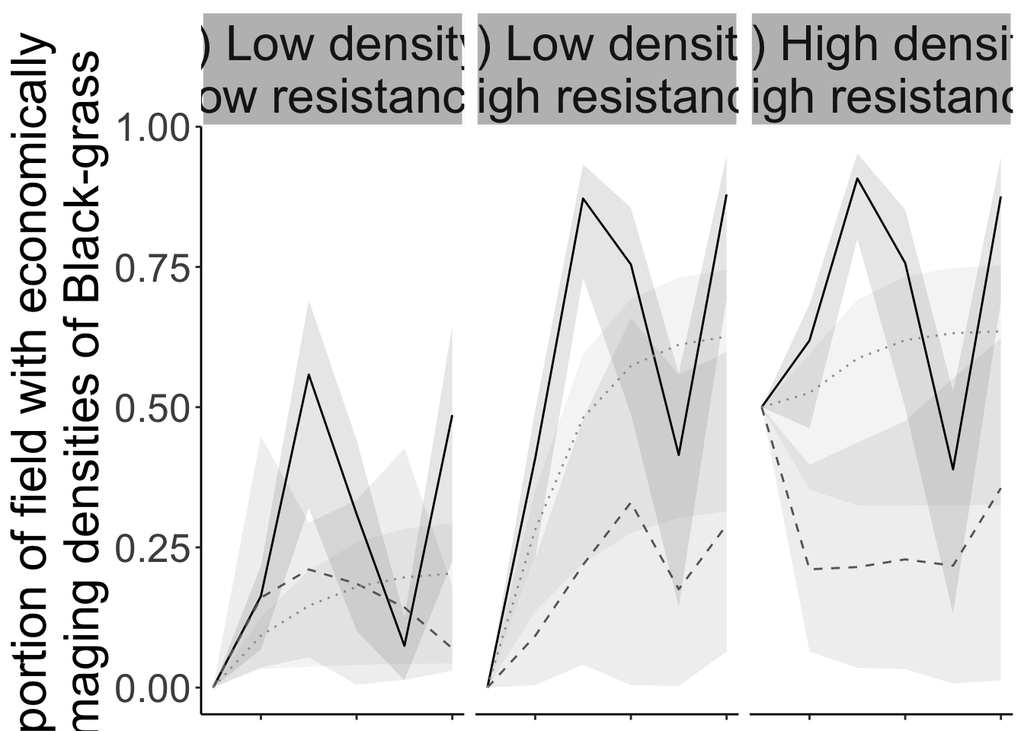

```r
fig3a <- ggplot(hvh_yr_s_idr,
       aes(x = year, y = hvh, group = scenario, colour = scenario, linetype=scenario)) +
  facet_wrap(~initDR, labeller = labeller(initDR = initDR.labs)) +
  geom_ribbon(aes(ymin = hvh_min, ymax = hvh_max, fill = scenario),
              alpha = 0.1, # controls transparency
              linetype = "blank" # gets rid of upper and lower lines
              ) +
  geom_line() +
  scale_linetype_manual(name = "Scenario", values=c(1,2,3)) + #line types: 1 bold, 2 dashed, 3 dotted
  scale_fill_manual(
    name = "Scenario",
    values = c("black", # BAU
               "grey40",  # MIT
               "grey61" # CWW
               )
    ) +
  scale_color_manual(
    name = "Scenario",
    values = c("black", # BAU
               "grey40",  # MIT
               "grey61" # CWW
               )
    ) +
  theme_classic() +
  labs(#x = "Year in rotation",
       y = "Proportion of field with economically\ndamaging densities of Black-grass") +
  theme(
    panel.grid.major = element_blank(),
    panel.grid.minor = element_blank(),
    plot.title = element_blank(),
    axis.title=element_text(size=24),
    axis.title.x=element_blank(),
    axis.text.x=element_blank(), #remove x axis labels
    #axis.text.x=element_text(size=rel(2.2)),
    axis.text.y=element_text(size=rel(2.2)),
    legend.title=element_text(size=24),
    legend.text=element_text(size=24),
    strip.background = element_rect(color = "white",
                                    fill = "grey"),# colour of rectangle round region labels
    strip.text = element_text(size = 24)
    ) +
  theme(legend.position="none")

rm(hvh_yr_s_idr)
fig3a
```

### 3.3.3. Summarise gross profit data

Calculate mean gross profit plus min and max values for each scenario, year and initial density and resistance level.

```r
mean_gp <- econ_curr %>%
  group_by(scenario, year, initDR) %>%
  dplyr::mutate(
    gp = mean(gpmean),
    gp_min = min(gpmean),
    gp_max = max(gpmean),
    ) %>%
  distinct(scenario, year, initDR, .keep_all = TRUE) %>%
  dplyr::select(scenario, year, initDR, gp, gp_min, gp_max) %>%
  dplyr::mutate(scenario = factor(scenario, levels = c("BAU", "MIT", "CWW")))
```

### 3.3.4. Plot Fig 3b

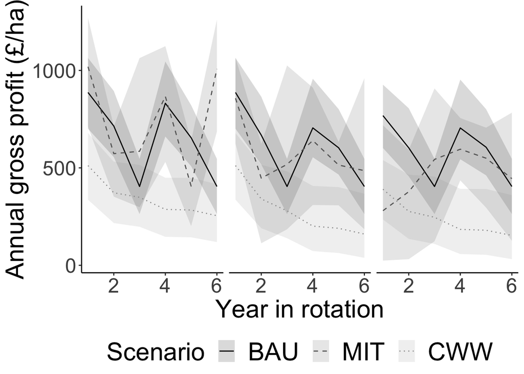

```r
fig3b <- ggplot(mean_gp, aes(x = year, y = gp, group = scenario, colour = scenario, linetype=scenario)) +
  facet_wrap(~initDR, labeller = labeller(initDR = initDR.labs)) +
  geom_ribbon(aes(ymin = gp_min, ymax = gp_max, fill = scenario),
              alpha = 0.15, # controls transparency
              linetype = "blank" # gets rid of upper and lower lines
              ) +
  geom_line() +
  scale_linetype_manual(name = "Scenario", values=c(1,2,3)) + #line types: 1 bold, 2 dashed, 3 dotted
  scale_fill_manual(
    name = "Scenario",
    values = c("black", # BAU
               "grey40",  # MIT
               "grey61" # CWW
               )
    ) +
  scale_color_manual(
    name = "Scenario",
    values = c("black", # BAU
               "grey40",  # MIT
               "grey61" # CWW
               )
    ) +
  theme_classic() +
  labs(x = "Year in rotation",
       y = "Annual gross profit (£/ha)") +
  theme(
    panel.grid.major = element_blank(),
    panel.grid.minor = element_blank(),
    plot.title = element_blank(),
    axis.title=element_text(size=24),
    axis.text.x=element_text(size=rel(2.2)),
    axis.text.y=element_text(size=rel(2.2)),
    strip.text.x = element_blank(), #remove facet labels
    legend.position="bottom",
    legend.title=element_text(size=24),
    legend.text=element_text(size=24),
    strip.background = element_rect(color = "white",
                                    fill = "grey"),# colour of rectangle round region labels
    strip.text = element_text(size = 24)
    )

fig3b
```

### 3.3.5. Plot Fig 3 and save

Specify panel plot, save.

```r
fig3 <- (fig3a + fig3b) +
  plot_layout(ncol=1) +
  plot_annotation(tag_levels = 'a', tag_prefix = '(',  tag_suffix = ')') &
  theme(plot.tag = element_text(size = 24, face="bold"))

png("../figures/Figure_3.png",
    height = 15, width = 20, units = "in", res = 300)
print(fig3)
dev.off()
```

## 3.4. Figure 4 - stacked bar plot, cost components

### 3.4.1. Summarise data

Find the rotation mean values for each scenario and initial den-res.

```r
rotn_means <- econ_curr %>%
  # find rotation mean
  dplyr::group_by(scenario, region, soiltype, initDR) %>%
  dplyr::summarise(across(c(gpmean:other),.fns = list(
    mean=~mean(.x, na.rm = TRUE),
    n=~nobs(.x) # should all be 6
    ))) %>%
  rename_with(~str_replace(., 'mean_', '_')) %>%  # strip out the unnecessary 'mean' in column names
  ungroup() %>%

  # then find mean across scenario and initdenres
  dplyr::group_by(scenario, initDR) %>%
  dplyr::summarise(across(ends_with("mean"),.fns = list(
    mean=~mean(.x, na.rm = TRUE),
    min =~min(.x, na.rm = TRUE),
    max =~max(.x, na.rm = TRUE),
    n=~nobs(.x)
    ))) %>%
  rename_with(~str_replace(., '_mean_', '_')) %>%
  ungroup()
```

Get the data into a different format for plotting.

```r
df_for_stack <- rotn_means %>%
  dplyr::filter(!scenario == "CWW") %>%
  droplevels() %>%
  dplyr::mutate(xval = paste(scenario, initDR, sep="_")) %>%
  dplyr::select(-c('scenario','initDR')) %>%
  dplyr::select(xval, herbcost_mean, ops_mean, cyl_mean, other_mean) %>%
  rename_with(~str_replace(., '_mean', '')) %>%
  pivot_longer(!xval, names_to = "cost", values_to = "amount") %>%
  dplyr::mutate(cost = factor(cost, levels=c("herbcost", "cyl", "ops", "other"))) %>%
  dplyr::filter(!cost == "cyl") %>%
  dplyr::mutate(xval = factor(xval, levels = c("BAU_LD-LR", "BAU_LD-HR", "BAU_HD-HR", "MIT_LD-LR", "MIT_LD-HR", "MIT_HD-HR"))) #specify order of factor levels for plot
```

### 3.4.2. Print max and min values for error bars

```r
rotn_means %>%
  dplyr::filter(!scenario == "CWW") %>%
  dplyr::select(c(scenario, initDR, gp_mean, gp_min, gp_max, output_mean:output_max, potout_mean:potout_max))
```

```
## # A tibble: 6 × 11
##   scenario initDR gp_mean gp_min gp_max output_mean output_min output_max
##   <fct>    <fct>    <dbl>  <dbl>  <dbl>       <dbl>      <dbl>      <dbl>
## 1 BAU      LD-LR     649.   492.   820.       1416.      1216.      1614.
## 2 BAU      LD-HR     612.   461.   797.       1378.      1184.      1591.
## 3 BAU      HD-HR     582.   432.   763.       1349.      1157.      1559.
## 4 MIT      LD-LR     743.   553.   891.       1443.      1237.      1645.
## 5 MIT      LD-HR     577.   468.   743.       1323.      1146.      1550.
## 6 MIT      HD-HR     465.   363.   596.       1196.       986.      1392.
## # ℹ 3 more variables: potout_mean <dbl>, potout_min <dbl>, potout_max <dbl>
```

### 3.4.3. Plot Fig 4 and save

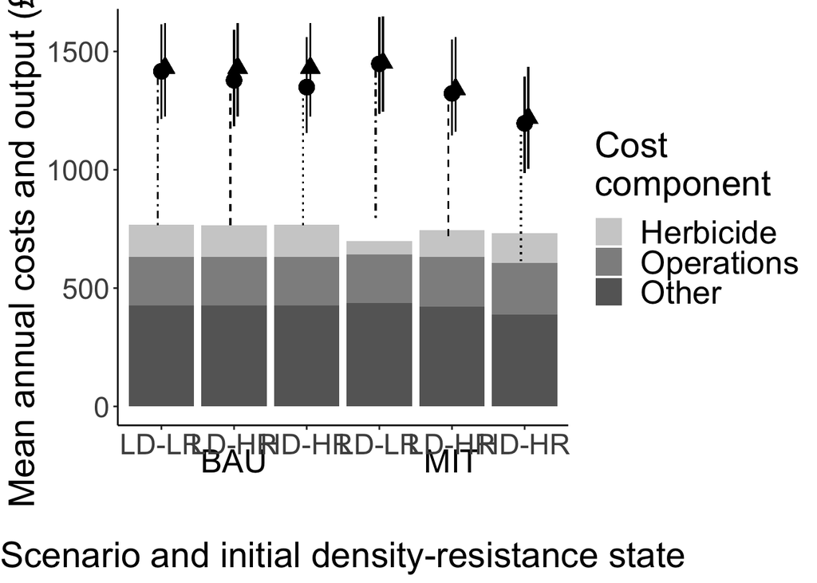

```r
fig4 <- ggplot(df_for_stack, aes(x=xval, y=amount, fill=cost)) +
  geom_bar(position="stack", stat="identity") +
  scale_fill_manual(
    name = "Cost \ncomponent",
    values = c('grey81', 'grey56', 'grey40'),
    labels = c('Herbicide', 'Operations', 'Other') # 'Lost yield',
    ) +

  # 1. BAU LD-LR

  ## output
  geom_point(aes(x = 1, y = 1416.308), cex = 4, show.legend = FALSE) + # point
  geom_segment(aes(x = 1, y = 1215.7172, xend = 1, yend = 1613.962)) + # min, max

  ## potential output (output with no BG)
  geom_point(aes(x = 1.05, y = 1431.293), cex = 4, shape = 17, show.legend = FALSE) + # point
  geom_segment(aes(x = 1.05, y = 1226.775, xend = 1.05, yend = 1619.083)) + # min, max
  #geom_segment(aes(x = 1.05, y = 1320.006, xend = 1.05, yend = 1542.580)) + # CIs

  ## gross profit line
  geom_segment(aes(x = 0.95, y = 1416.308-649.4691, xend = 0.95, yend = 1416.308, linetype = 'dotdash')) + # diff = gp 649.4691

  # 2. BAU LD-HR

  ## output
  geom_point(aes(x = 2, y = 1378.1), cex = 4, show.legend = FALSE) + # point
  geom_segment(aes(x = 2, y = 1184.2618, xend = 2, yend = 1590.811)) + # min, max
  #geom_segment(aes(x = 2, y = 1271.964, xend = 2, yend = 1484.184)) + # CIs

  ## output with no BG
  geom_point(aes(x = 2.05, y = 1431.293), cex = 4, shape = 17, show.legend = FALSE) + # point
  geom_segment(aes(x = 2.05, y = 1226.775, xend = 2.05, yend = 1619.083)) + # min, max
  #geom_segment(aes(x = 2.05, y = 1320.006, xend = 2.05, yend = 1542.580)) + # CIs

  ## gross profit line
  geom_segment(aes(x = 1.95, y = 1378.1-612.0344, xend = 1.95, yend = 1378.1, linetype = 'dashed')) + # diff = 612.0344

  # 3. BAU HD-HR

  ## output
  geom_point(aes(x = 3, y = 1349.2), cex = 4, show.legend = FALSE) + # point
  geom_segment(aes(x = 3, y = 1156.7115, xend = 3, yend = 1558.674)) + # min, max
  #geom_segment(aes(x = 3, y = 1244.473, xend = 3, yend = 1453.913)) + # CIs

  ## output with no BG
  geom_point(aes(x = 3.05, y = 1431.293), cex = 4, shape = 17, show.legend = FALSE) +
  geom_segment(aes(x = 3.05, y = 1226.775, xend = 3.05, yend = 1619.083)) + # min, max
  #geom_segment(aes(x = 3.05, y = 1320.006, xend = 3.05, yend = 1542.580)) + # CIs

  ## gross profit line
  geom_segment(aes(x = 2.95, y = 1349.2-581.7659, xend = 2.95, yend = 1349.2, linetype = 'dotted')) + scale_linetype_identity() +

  # 4. MIT LD-LR

  ## output
  geom_point(aes(x = 4, y = 1447.7), cex = 4, show.legend = FALSE) + # point #colour = "#020E20",
  geom_segment(aes(x = 4, y = 1237.4226, xend = 4, yend = 1644.501)) + # min, max
  #geom_segment(aes(x = 4, y = 1349.828, xend = 4, yend = 1545.666)) + # CIs

  ## output with no BG
  geom_point(aes(x = 4.05, y = 1452.119), cex = 4, shape = 17, show.legend = FALSE) + # point
  geom_segment(aes(x = 4.05, y = 1246.485, xend = 4.05, yend = 1647.453)) + # min, max
  #geom_segment(aes(x = 4.05, y = 1354.349, xend = 4.05, yend = 1549.890)) + # CIs

  ## gross profit from BAU scenario
  geom_segment(aes(x = 3.95, y = 1447.7-649.4691, xend = 3.95, yend = 1447.7, linetype = 'dotdash')) +

  # 5. MIT LD-HR

  ## output
  geom_point(aes(x = 5, y = 1322.507), cex = 4, show.legend = FALSE) + # point
  geom_segment(aes(x = 5, y = 1145.681, xend = 5, yend = 1550.266)) + # min, max
  #geom_segment(aes(x = 5, y = 1250.360, xend = 5, yend = 1413.200)) + # CIs

  ## output with no BG
  geom_point(aes(x = 5.05, y = 1340.811), cex = 4, shape = 17, show.legend = FALSE) + # point
  geom_segment(aes(x = 5.05, y = 1161.817, xend = 5.05, yend = 1560.050)) + # min, max
  #geom_segment(aes(x = 5.05, y = 1259.247, xend = 5.05, yend = 1422.375)) + # CIs

  ## gross profit from BAU scenario
  geom_segment(aes(x = 4.95, y = 1331.78-612.0344, xend = 4.95, yend = 1331.78, linetype = 'dashed')) + # diff = 612.0344


  # 6. MIT HD-HR

  ## output
  geom_point(aes(x = 6, y = 1196.057), cex = 4, show.legend = FALSE) + # point #colour = "#020E20",
  geom_segment(aes(x = 6, y = 986.334, xend = 6, yend = 1392.248)) + # min, max
  #geom_segment(aes(x = 6, y = 1108.905, xend = 6, yend = 1272.553)) + # CIs

  ## output with no BG
  geom_point(aes(x = 6.05, y = 1218.576), cex = 4, shape = 17, show.legend = FALSE) + # point
  geom_segment(aes(x = 6.05, y = 1004.978, xend = 6.05, yend = 1433.782)) + # min, max
  #geom_segment(aes(x = 6.05, y = 1137.202, xend = 6.05, yend = 1299.950)) + # CIs

  ## gross profit from BAU scenario
  geom_segment(aes(x = 5.95, y = 1196.057-581.7659, xend = 5.95, yend = 1196.057, linetype = 'dotted')) +

  labs(x = "\n\nScenario and initial density-resistance state",
       y = "Mean annual costs and output (£/ha)") +
  scale_x_discrete(labels=c('LD-LR', 'LD-HR', 'HD-HR',
                              'LD-LR', 'LD-HR', 'HD-HR')) +
  annotate("text", x=2, y=-230, label="BAU", size = 7) +
  annotate("text", x=5, y=-230, label="MIT", size = 7) +
  coord_cartesian(ylim=c(0,1600),clip="off") +
  theme_classic() +
  theme(axis.title=element_text(size=22),
        axis.text.x=element_text(size=rel(2)),#,
        axis.text.y=element_text(size=rel(2)),
        legend.title=element_text(size=22),
        legend.text=element_text(size=20)
        )

fig4
```

```r
png("../figures/Figure_4.png",
    height = 10, width = 17, units = "in", res = 300)
print(fig4)
dev.off()
```

## 3.5. Figure 5 - scatter plot, opportunity and productivity costs

### 3.5.1. Summarise opportunity costs

Create summarised data frame of *BAU, current density – MIT, current density* opportunity costs.

```r
oc_current <- econ_curr %>%
  dplyr::filter(scenario=="MIT") %>%
  # calculate rotation mean
  dplyr::group_by(scenario, region, soiltype, initDR) %>%
  dplyr::summarise(
    oc = mean(ocmean, na.rm = TRUE),
    oc_min = min(ocmean, na.rm = TRUE),
    oc_max = max(ocmean, na.rm = TRUE)
    ) %>%
  arrange(scenario, region, soiltype, initDR) %>%
  dplyr::mutate(situation="Current") %>%
  ungroup() %>%
  dplyr::select(-scenario)
```

### 3.5.2. Plot Fig 5a - annual opportunity costs

Specify the labels for the panels.

```r
region.labs <- c("Northern England", "Central England", "Eastern England") # new
names(region.labs) <- c("n", "c", "e") # original

soiltype.labs <- c("Heavy soil", "Medium soil", "Light soil") # new
names(soiltype.labs) <- c("h", "m", "l") # original
```

Specify the plot annotations. These will show the **numbers of spring crops and winter wheat crops** in each rotation.

```r
anno_oc <- data.frame(
  x = c("HD-HR","HD-HR","HD-HR",
        "HD-HR","HD-HR","HD-HR",
        "HD-HR","HD-HR","HD-HR",
        "LD-HR","LD-HR","LD-HR",
        "LD-HR","LD-HR","LD-HR",
        "LD-HR","LD-HR","LD-HR",
        "LD-LR","LD-LR","LD-LR",
        "LD-LR","LD-LR","LD-LR",
        "LD-LR","LD-LR","LD-LR"
        ),
  y = c(-550,-550,-550,
        -550,-550,-550,
        -550,-550,-550,
        -550,-550,-550,
        -550,-550,-550,
        -550,-550,-550,
        -550,-550,-550,
        -550,-550,-550,
        -550,-550,-550
        ),
  # numbers of spring / ww crops:
  lab = c("s3,w2", "s3,w2", "s3,w2", # north, HD-HR
          "s3,w2", "s3,w2", "s3,w2", # central, HD-HR
          "s4,w2", "s4,w2", "s4,w2", # east, HD-HR

          "s2,w2", "s2,w2", "s2,w2", # north, LD-HR
          "s2,w2", "s2,w2", "s2,w2", # central, LD-HR
          "s1,w3", "s1,w3", "s1,w3", # east, LD-HR

          "s1,w3", "s1,w3", "s1,w3", # north, LD-LR
          "s1,w3", "s1,w3", "s1,w3", # central, LD-LR
          "s0,w4", "s0,w4", "s0,w4"  # east, LD-LR
          ),
  region = c("n", "n", "n",
             "c", "c", "c",
             "e", "e", "e",
             "n", "n", "n",
             "c", "c", "c",
             "e", "e", "e",
             "n", "n", "n",
             "c", "c", "c",
             "e", "e", "e"
             ),
  soiltype = c("h", "m", "l",
               "h", "m", "l",
               "h", "m", "l",
               "h", "m", "l",
               "h", "m", "l",
               "h", "m", "l",
               "h", "m", "l",
               "h", "m", "l",
               "h", "m", "l"
               ),
  situation = c("Current", "Current", "Current",
                "Current", "Current", "Current",
                "Current", "Current", "Current",
                "Current", "Current", "Current",
                "Current", "Current", "Current",
                "Current", "Current", "Current",
                "Current", "Current", "Current",
                "Current", "Current", "Current",
                "Current", "Current", "Current"
                )
           ) %>%
  dplyr::mutate(
    region = factor(region,
                    levels = c("n", "c", "e")
                    ),
    soiltype = factor(soiltype,
                    levels = c("h", "m", "l")
                    )
  )
```

Specify the plot.

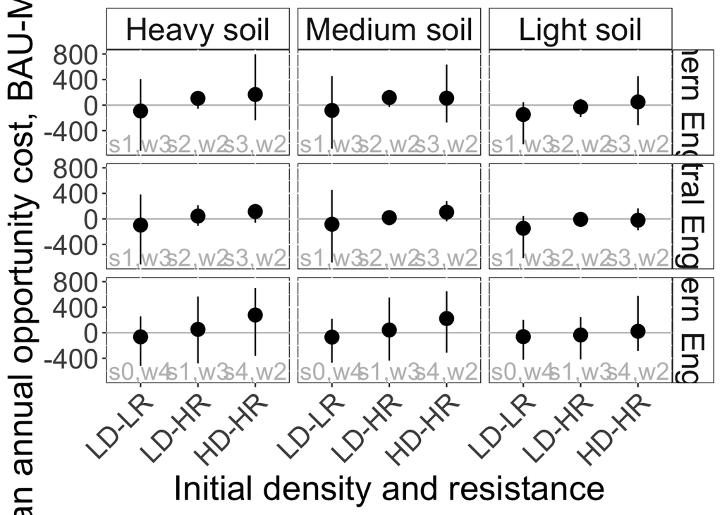

```r
fig5a <- ggplot(
  oc_current, aes(initDR, oc*(-1))) +
  facet_grid(region ~ soiltype,
             labeller = labeller(region = region.labs,
                                 soiltype = soiltype.labs)
  ) +
  scale_x_discrete(guide = guide_axis(angle = 45)) +
  geom_hline(aes(yintercept = 0), color="grey") + #, linetype="dashed"
  labs(x = "Initial density and resistance",
       y = "Mean annual opportunity cost, BAU-MIT (£/ha)") +
  theme(strip.placement = 'outside',
        panel.background = element_rect(fill = "white", colour = "black"),# white background in main panels
        strip.background = element_rect(fill = "white", colour = "black"), # white background in strips
        strip.text.x = element_text(size = 22),
        strip.text.y = element_text(size = 22),
        axis.title=element_text(size=24),
        axis.text.x=element_text(size=rel(2.2)),
        axis.text.y=element_text(size=rel(2.2))
        ) +
  geom_pointrange(aes(ymin = oc_max*(-1),
                      ymax = oc_min*(-1)
                      ),
                  position=position_dodge(width=0.3),
                  size = 0.9) +
  geom_text(data = anno_oc, aes(x = x,  y = -600, label = lab),
           colour = "grey",  size=6) +
  theme(legend.position="none")

fig5a
```

### 3.5.3. Summarise productivity costs

Create summarised data frame of *BAU, current density – MIT, current density* productivity costs.

```r
pc_current <- econ_curr %>%
  dplyr::filter(scenario=="MIT") %>%
  # calculate rotation mean
  dplyr::group_by(scenario, region, soiltype, initDR) %>%
  dplyr::summarise(
    pc = mean(pcmean, na.rm = TRUE),
    pc_min = min(pcmean, na.rm = TRUE),
    pc_max = max(pcmean, na.rm = TRUE)
    ) %>%
  arrange(scenario, region, soiltype, initDR) %>%
  dplyr::mutate(situation="Current") %>%
  ungroup() %>%
  dplyr::select(-scenario)
```

### 3.5.4. Plot Fig 5b - annual productivity costs

Panel labels as for Fig5a.

Specify annotations. These show **numbers of winter wheat crops** in each rotation.

```r
anno_pc <- data.frame(
  x = c("HD-HR","HD-HR","HD-HR",
        "HD-HR","HD-HR","HD-HR",
        "HD-HR","HD-HR","HD-HR",
        "LD-HR","LD-HR","LD-HR",
        "LD-HR","LD-HR","LD-HR",
        "LD-HR","LD-HR","LD-HR",
        "LD-LR","LD-LR","LD-LR",
        "LD-LR","LD-LR","LD-LR",
        "LD-LR","LD-LR","LD-LR"
        ),
  y = c(-6.2,-6.2,-6.2,
        -6.2,-6.2,-6.2,
        -6.2,-6.2,-6.2,
        -6.2,-6.2,-6.2,
        -6.2,-6.2,-6.2,
        -6.2,-6.2,-6.2,
        -6.2,-6.2,-6.2,
        -6.2,-6.2,-6.2,
        -6.2,-6.2,-6.2
        ),
  # numbers of winter wheat crops:
  lab = c("2", "2", "2", # north, HD-HR
          "2", "2", "2", # central, HD-HR
          "2", "2", "2", # east, HD-HR

          "2", "2", "2", # north, LD-HR
          "2", "2", "2", # central, LD-HR
          "3", "3", "3", # east, LD-HR

          "3", "3", "3", # north, LD-LR
          "3", "3", "3", # central, LD-LR
          "4", "4", "4"  # east, LD-LR
          ),
  region = c("n", "n", "n",
             "c", "c", "c",
             "e", "e", "e",
             "n", "n", "n",
             "c", "c", "c",
             "e", "e", "e",
             "n", "n", "n",
             "c", "c", "c",
             "e", "e", "e"
             ),
  soiltype = c("h", "m", "l",
               "h", "m", "l",
               "h", "m", "l",
               "h", "m", "l",
               "h", "m", "l",
               "h", "m", "l",
               "h", "m", "l",
               "h", "m", "l",
               "h", "m", "l"
               ),
  situation = c("Current", "Current", "Current",
                "Current", "Current", "Current",
                "Current", "Current", "Current",
                "Current", "Current", "Current",
                "Current", "Current", "Current",
                "Current", "Current", "Current",
                "Current", "Current", "Current",
                "Current", "Current", "Current",
                "Current", "Current", "Current"
                )
           ) %>%
  dplyr::mutate(
    region = factor(region,
                    levels = c("n", "c", "e")
                    ),
    soiltype = factor(soiltype,
                    levels = c("h", "m", "l")
                    )
  )
```

Specify the plot.

[figure not shown]

```r
fig5b <- ggplot(
  pc_current, aes(initDR, pc*(-1))) +
  facet_grid(region ~ soiltype,
             labeller = labeller(region = region.labs,
                                 soiltype = soiltype.labs)) +
  ylim(-12, 9) +
  scale_x_discrete(guide = guide_axis(angle = 45)) +
  geom_hline(aes(yintercept = 0), color="grey") +
  labs(x = "Initial density and resistance",
       y = "Mean annual productivity cost, BAU-MIT (t/ha)") +
  theme(strip.placement = 'outside',
        panel.background = element_rect(fill = "white", colour = "black"),# white background in main panels
        strip.background = element_rect(fill = "white", colour = "black"), # white background in strips
        strip.text.x = element_text(size = 22),
        strip.text.y = element_text(size = 22),
        axis.title=element_text(size=24),
        axis.text.x=element_text(size=rel(2.2)),
        axis.text.y=element_text(size=rel(2.2)),
        #legend.title=element_text(size=24),
        #legend.text=element_text(size=24),
        #legend.key = element_blank(),# removes grey background behind symbols in legend
        ) +
  geom_pointrange(aes(ymin = pc_max*(-1), ymax = pc_min*(-1)),
                  position=position_dodge(width=0.3),
                  size = 0.9) +
  geom_text(data = anno_pc, aes(x = x,  y = -10.8, label = lab), colour = "grey",  size=6)

fig5b
```

### 3.5.5. Plot Fig 5 and save

Specify panel plot, save.

```r
fig5 <- (fig5a + fig5b) +
  plot_annotation(tag_levels = 'a', tag_prefix = '(',  tag_suffix = ')') &
  theme(plot.tag = element_text(size = 24, face="bold"))

png("../figures/Figure_5.png",
    height = 10, width = 20, units = "in", res = 300)
print(fig5)
dev.off()
```

## 3.6. Figure 6 - Cumulative opportunity and productivity costs per strategy

### 3.6.1. Calculate cumulative opportunity and productivity costs

#### Opportunity costs

For each strategy (i.e., for each soil type, region and initial den res), find the average cumulative opportunity cost of doing something other than BBB.

```r
cum_oc <- weighted_worstcase %>%

  # Find cumulative totals (i.e. sum over 18 years) for each imputation
  dplyr::group_by(imp, rotn_seq, region, soiltype, initdenres) %>%
  dplyr::mutate(
    cum_tot_gp = sum(wtd_gp),
    cum_tot_oc = sum(wtd_opp_cost)
    ) %>%
  dplyr::distinct(imp, rotn_seq, region, soiltype, initdenres, .keep_all = TRUE) %>%
  dplyr::select(imp, rotn_seq, scenario, region, soiltype, initdenres, initcondit, cum_tot_gp, cum_tot_oc) %>%
  ungroup() %>%

  # Calculate mean cumulative gross profit and opportunity costs across imputations, plus max and min values from imputations
  dplyr::group_by(rotn_seq, region, soiltype, initdenres) %>%
  dplyr::mutate(

    # gross profit
    cum_tot_gp_across_imp = mean(cum_tot_gp),
    cum_tot_gp_across_imp_min = min(cum_tot_gp),
    cum_tot_gp_across_imp_max = max(cum_tot_gp),

    # opportunity costs
    cum_tot_oc_across_imp = mean(cum_tot_oc),
    cum_tot_oc_across_imp_min = min(cum_tot_oc),
    cum_tot_oc_across_imp_max = max(cum_tot_oc)

    ) %>%
  dplyr::distinct(rotn_seq, region, soiltype, initdenres, .keep_all = TRUE) %>%
  dplyr::select(-c(imp, cum_tot_gp)) %>%
  ungroup() %>%

  # Create new den-res categories
  dplyr::mutate(
    initDR = fct_recode(initdenres,
                        "LD-LR" = "MD-LR", # LD-LR & MD-LR (best case)
                        "LD-HR" = "MD-HR", # LD-HR & MD-HR (intermediate case)
                        "HD-HR" = "VD-HR"  # HD-HR & VD-HR (worst case)
                        ),
    initDR = factor(initDR, levels = c("LD-LR","LD-HR","HD-HR")) # specify order of new levels
    ) %>%
  ungroup() %>%

  # Calculate mean cumulative total gross profit and opportunity costs across new den-res levels
  dplyr::group_by(rotn_seq, region, soiltype, initDR) %>%
  dplyr::mutate(

    # gross profit
    cum_tot_gp_mean = mean(cum_tot_gp_across_imp),
    cum_tot_gp_min = mean(cum_tot_gp_across_imp_min), # min value across all imputations from LD-LR runs
    cum_tot_gp_max = mean(cum_tot_gp_across_imp_max), # max value across all imputations from VD-HR runs

    # opportunity costs
    cum_tot_oc_mean = mean(cum_tot_oc_across_imp),
    cum_tot_oc_min = mean(cum_tot_oc_across_imp_min), # min value across all imputations from LD-LR runs
    cum_tot_oc_max = mean(cum_tot_oc_across_imp_max), # max value across all imputations from VD-HR runs

    ) %>%
  ungroup() %>%

  # Remove duplicates
  dplyr::distinct(rotn_seq, region, soiltype, initDR, .keep_all = TRUE) %>%

  # Retain just the useful columns
  dplyr::select(c(rotn_seq, scenario, region, soiltype, initDR,
                  cum_tot_gp_mean, cum_tot_gp_min, cum_tot_gp_max,
                  cum_tot_oc_mean, cum_tot_oc_min, cum_tot_oc_max)) %>%

  # specify how the data frame is ordered
  dplyr::arrange(rotn_seq, region, soiltype, initDR) %>%
  dplyr::relocate(cum_tot_gp_min, .after = cum_tot_gp_mean) %>%
  dplyr::relocate(cum_tot_gp_max, .after = cum_tot_gp_min) %>%
  dplyr::relocate(cum_tot_oc_min, .after = cum_tot_oc_mean) %>%
  dplyr::relocate(cum_tot_oc_max, .after = cum_tot_oc_min)
```

#### Productivity costs

For each strategy (i.e., for each soil type, region and initial den res), find the average cumulative productivity cost of doing something other than BBB.  
N.B. Only calculate productivity costs for winter wheat crops as we have no way of estimating the impact of weeds on yield of other crops.

```r
cum_pc <- weighted_worstcase %>%

  # Find cumulative wheat yield (i.e. sum over 18 years) for each imputation
  dplyr::group_by(imp, rotn_seq, region, soiltype, initdenres) %>%
  dplyr::mutate(
    cum_tot_ww = sum(ww_yield),
    cum_tot_pc = sum(wtd_prod_cost)
    ) %>%
  ungroup() %>%
  dplyr::distinct(imp, rotn_seq, region, soiltype, initdenres, .keep_all = TRUE) %>%
  dplyr::select(imp, rotn_seq, scenario, region, soiltype, initdenres, initcondit, cum_tot_ww, cum_tot_pc) %>%

  # Calculate mean cumulative wheat yield and productivity costs across imputations, plus max and min values from imputations
  dplyr::group_by(rotn_seq, region, soiltype, initdenres) %>%
  dplyr::mutate(

    # wheat yield
    cum_tot_ww_across_imp = mean(cum_tot_ww),
    cum_tot_ww_across_imp_min = min(cum_tot_ww),
    cum_tot_ww_across_imp_max = max(cum_tot_ww),

    # productivity costs
    cum_tot_pc_across_imp = mean(cum_tot_pc),
    cum_tot_pc_across_imp_min = min(cum_tot_pc),
    cum_tot_pc_across_imp_max = max(cum_tot_pc)

    ) %>%
  ungroup() %>%
  dplyr::distinct(rotn_seq, region, soiltype, initdenres, .keep_all = TRUE) %>%
  dplyr::select(-c(imp, cum_tot_ww, cum_tot_pc)) %>%

  # Create new den-res categories
  dplyr::mutate(
    initDR = fct_recode(initdenres,
                        "LD-LR" = "MD-LR", # LD-LR & MD-LR (best case)
                        "LD-HR" = "MD-HR", # LD-HR & MD-HR (intermediate case)
                        "HD-HR" = "VD-HR"  # HD-HR & VD-HR (worst case)
                        ),
    initDR = factor(initDR, levels = c("LD-LR","LD-HR","HD-HR")) # specify order of new levels
    ) %>%
  ungroup() %>%

  # Calculate mean cumulative wheat yield and productivity costs across new den-res levels
  dplyr::group_by(rotn_seq, region, soiltype, initDR) %>%
  dplyr::mutate(

    # gross profit
    cum_tot_ww_mean = mean(cum_tot_ww_across_imp),
    cum_tot_ww_min = mean(cum_tot_ww_across_imp_min), # min value across all imputations from LD-LR runs
    cum_tot_ww_max = mean(cum_tot_ww_across_imp_max), # max value across all imputations from VD-HR runs

    # opportunity costs
    cum_tot_pc_mean = mean(cum_tot_pc_across_imp),
    cum_tot_pc_min = mean(cum_tot_pc_across_imp_min), # min value across all imputations from LD-LR runs
    cum_tot_pc_max = mean(cum_tot_pc_across_imp_max)  # max value across all imputations from VD-HR runs

    ) %>%
  ungroup() %>%

  # Remove duplicates
  dplyr::distinct(rotn_seq, region, soiltype, initDR, .keep_all = TRUE) %>%

  # Retain just the useful columns
  dplyr::select(-c(initdenres, initcondit,
                   cum_tot_ww_across_imp, cum_tot_ww_across_imp_min, cum_tot_ww_across_imp_max,
                   cum_tot_pc_across_imp, cum_tot_pc_across_imp_min, cum_tot_pc_across_imp_max)
                ) %>%

  # Specify how the data frame is ordered
  dplyr::arrange(rotn_seq, region, soiltype, initDR) %>%
  dplyr::relocate(cum_tot_ww_min, .after = cum_tot_ww_mean) %>%
  dplyr::relocate(cum_tot_ww_max, .after = cum_tot_ww_min) %>%
  dplyr::relocate(cum_tot_pc_min, .after = cum_tot_pc_mean) %>%
  dplyr::relocate(cum_tot_pc_max, .after = cum_tot_pc_min)
```

### 3.6.2. Specify panel labels

```r
region.labs <- c("Northern England", "Central England", "Eastern England") # new
names(region.labs) <- c("n", "c", "e") # original

soiltype.labs <- c("Heavy soil", "Medium soil", "Light soil") # new
names(soiltype.labs) <- c("h", "m", "l") # original
```

### 3.6.3. Plot opportunity costs

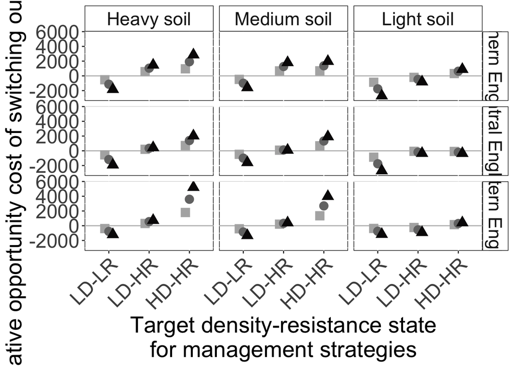

```r
fig6a <- ggplot(cum_oc %>%
  dplyr::filter(rotn_seq != "BBB"),
  aes(initDR, cum_tot_oc_mean*(-1),
                    colour = rotn_seq, shape = rotn_seq)) +
  facet_grid(region ~ soiltype,
             labeller = labeller(region = region.labs,
                                 soiltype = soiltype.labs)
  ) +
  scale_x_discrete(guide = guide_axis(angle = 45)) +
  geom_hline(aes(yintercept = 0), color="grey") + #, linetype="dashed"
  labs(x = "Target density-resistance state\nfor management strategies",
       y = "Cumulative opportunity cost of switching out of BBB (£/ha)") +
  # specify colours for 'sequence':
  scale_color_manual(name = "Sequence",
                     values = c(
                       "#B1B1B1", # BBM, pewter
                       "#747474", # BMM, grey
                       "#0A0708"  # MMM, ebony
                       )
                     ) +
  scale_shape_manual(name = "Sequence",
                     values=c(15, 16, 17)) + # BBM 15 square; BMM 16 circle, MMM triangle
  # Specify sizes, backgrounds etc.
  theme(strip.placement = 'outside',
        panel.background = element_rect(fill = "white", colour = "black"),# white background in main panels
        strip.background = element_rect(fill = "white", colour = "black"), # white background in strips
        strip.text.x = element_text(size = 18),
        strip.text.y = element_text(size = 18),
        plot.title = element_text(size=22),
        axis.title=element_text(size=22),
        axis.text.x=element_text(size=rel(2.2)),
        axis.text.y=element_text(size=rel(2.2))
        ) +
  geom_pointrange(aes(
    ymin = cum_tot_oc_min*(-1), ymax = cum_tot_oc_max*(-1)),
    position=position_dodge(width=0.3),
    size = 0.9) +
  theme(legend.position="none")

fig6a
```

### 3.6.4. Plot productivity costs

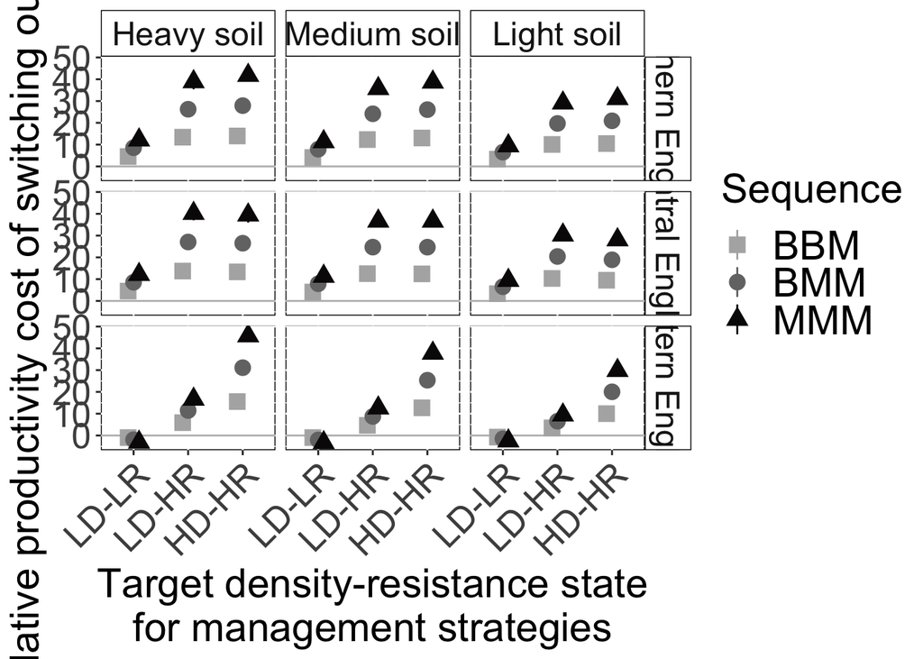

```r
fig6b <- ggplot(cum_pc %>% dplyr::filter(rotn_seq != "BBB"),
                             aes(initDR, cum_tot_pc_mean*(-1),
                    colour = rotn_seq, shape = rotn_seq)) +
  facet_grid(region ~ soiltype,
             labeller = labeller(region = region.labs,
                                 soiltype = soiltype.labs)
  ) +
  scale_x_discrete(guide = guide_axis(angle = 45)) +
  geom_hline(aes(yintercept = 0), color="grey") + #, linetype="dashed"
  labs(x = "Target density-resistance state\nfor management strategies",
       y = "Cumulative productivity cost of switching out of BBB (t/ha)") +
  # specify colours for 'sequence':
  scale_color_manual(name = "Sequence",
                     values = c(
                       "#B1B1B1", # BBM, pewter
                       "#747474", # BMM, grey
                       "#0A0708"  # MMM, ebony
                       )
                     ) +
  scale_shape_manual(name = "Sequence",
                     values=c(15, 16, 17)) + # BBM 15 square; BMM 16 circle, MMM triangle
  # Specify sizes, backgrounds etc.
  theme(strip.placement = 'outside',
        panel.background = element_rect(fill = "white", colour = "black"),# white background in main panels
        strip.background = element_rect(fill = "white", colour = "black"), # white background in strips
        strip.text.x = element_text(size = 18),
        strip.text.y = element_text(size = 18),
        plot.title = element_text(size=22),
        axis.title=element_text(size=22),
        axis.text.x=element_text(size=rel(2.2)),
        axis.text.y=element_text(size=rel(2.2)),
        legend.title=element_text(size=22),
        legend.text=element_text(size=22),
        legend.key = element_blank(),# removes grey background behind symbols in legend
        ) +
  geom_pointrange(aes(
    ymin = cum_tot_pc_min*(-1), ymax = cum_tot_pc_max*(-1)),
    position=position_dodge(width=0.3),
    size = 0.9)

fig6b
```

### 3.6.5. Specify panel plot and save

```r
fig6 <- (fig6a + fig6b) +
  plot_annotation(tag_levels = 'a', tag_prefix = '(',  tag_suffix = ')') &
  theme(plot.tag = element_text(size = 24, face="bold"))

png("../figures/Figure_6.png",
    height = 10, width = 20, units = "in", res = 300)
print(fig6)
dev.off()
```

# 4. Supplementary Figures and Tables

## 4.1. Table S5 - Herbicides applied on all crops

```r
tblS5 <- strats %>%
  dplyr::group_by(scenario, initdenres) %>%
  dplyr::filter(initdenres %in% c("LD-LR", "LD-HR", "HD-HR")) %>%
  dplyr::summarise(
    n_actives_mean = mean(h_bc_app), # calculate mean number of actives applied
    n_actives_se = sd(h_bc_app)/sqrt(nobs((h_bc_app))),
    sel_herb_vol_mean = mean(vol_sel_herb), # calculate mean volume of selective herbicide applied
    sel_herb_vol_se = sd(vol_sel_herb)/sqrt(nobs((vol_sel_herb))),
    sel_herb_vol_max = max(vol_sel_herb, na.rm=TRUE), # calculate max volume of selective herbicide applied
    gly_vol_mean = mean(vol_gly), # calculate mean volume of glyphosate applied
    gly_vol_se = sd(vol_gly)/sqrt(nobs((vol_gly))),
    gly_vol_max = max(vol_gly, na.rm=TRUE),
    n_autgly_mean = mean(a_gly), # calculate mean number of autumn glyphosate applications
    n_autgly_se = sd(a_gly)/sqrt(nobs((a_gly))),
    n_autgly_max = max(a_gly, na.rm=TRUE), # calculate max number of autumn glyphosate applications
    n_applic_mean = mean(spray_days), # calculate mean number of spraying days (i.e. mean number of applications)
    n_applic_se = sd(spray_days)/sqrt(nobs((spray_days)))
    ) %>%
  dplyr::mutate(across(where(is.numeric), ~round(.x, 2))) %>%
  dplyr::arrange(scenario, initdenres) %>%
  dplyr::relocate(c(n_applic_mean, n_applic_se), .after = initdenres)
# Save
write.csv(tblS5,  '../output/Table_S5.csv', row.names = FALSE)

tblS5
```

```
## # A tibble: 9 × 15
## # Groups:   scenario [3]
##   scenario initdenres n_applic_mean n_applic_se n_actives_mean n_actives_se
##   <fct>    <fct>              <dbl>       <dbl>          <dbl>        <dbl>
## 1 BAU      LD-LR               3.67        0.08           5            0.24
## 2 BAU      LD-HR               3.67        0.08           5            0.24
## 3 BAU      HD-HR               3.67        0.08           5            0.24
## 4 MIT      LD-LR               2.67        0.2            3.89         0.32
## 5 MIT      LD-HR               4.03        0.16           3.92         0.15
## 6 MIT      HD-HR               5.03        0.18           3.61         0.27
## 7 CWW      LD-LR               5           0              5            0
## 8 CWW      LD-HR               5           0              5            0
## 9 CWW      HD-HR               5           0              5            0
## # ℹ 9 more variables: sel_herb_vol_mean <dbl>, sel_herb_vol_se <dbl>,
## #   sel_herb_vol_max <dbl>, gly_vol_mean <dbl>, gly_vol_se <dbl>,
## #   gly_vol_max <dbl>, n_autgly_mean <dbl>, n_autgly_se <dbl>,
## #   n_autgly_max <dbl>
```

## 4.2. Table S6 - Herbicides applied on winter wheat

```r
tblS6 <- strats %>%
  dplyr::group_by(scenario, initdenres) %>%
  dplyr::filter(initdenres %in% c("LD-LR", "LD-HR", "HD-HR") & crop == "winter wheat") %>%
  dplyr::summarise(
    n_actives_mean = mean(h_bc_app), # calculate mean number of actives applied
    n_actives_se = sd(h_bc_app)/sqrt(nobs((h_bc_app))),
    sel_herb_vol_mean = mean(vol_sel_herb), # calculate mean volume of selective herbicide applied
    sel_herb_vol_se = sd(vol_sel_herb)/sqrt(nobs((vol_sel_herb))),
    sel_herb_vol_max = max(vol_sel_herb, na.rm=TRUE), # calculate max volume of selective herbicide applied
    gly_vol_mean = mean(vol_gly), # calculate mean volume of glyphosate applied
    gly_vol_se = sd(vol_gly)/sqrt(nobs((vol_gly))),
    gly_vol_max = max(vol_gly, na.rm=TRUE),
    n_autgly_mean = mean(a_gly), # calculate mean number of autumn glyphosate applications
    n_autgly_se = sd(a_gly)/sqrt(nobs((a_gly))),
    n_autgly_max = max(a_gly, na.rm=TRUE), # calculate max number of autumn glyphosate applications
    n_applic_mean = mean(spray_days), # calculate mean number of spraying days (i.e. mean number of applications)
    n_applic_se = sd(spray_days)/sqrt(nobs((spray_days)))
    ) %>%
  dplyr::mutate(across(where(is.numeric), ~round(.x, 2))) %>%
  dplyr::arrange(scenario, initdenres) %>%
  dplyr::relocate(c(n_applic_mean, n_applic_se), .after = initdenres)
# Save
write.csv(tblS6,  '../output/Table_S6.csv', row.names = FALSE)

tblS6
```

```
## # A tibble: 9 × 15
## # Groups:   scenario [3]
##   scenario initdenres n_applic_mean n_applic_se n_actives_mean n_actives_se
##   <fct>    <fct>              <dbl>       <dbl>          <dbl>        <dbl>
## 1 BAU      LD-LR               4           0              6            0
## 2 BAU      LD-HR               4           0              6            0
## 3 BAU      HD-HR               4           0              6            0
## 4 MIT      LD-LR               3.4         0.11           5.4          0.11
## 5 MIT      LD-HR               4.29        0.13           4.29         0.13
## 6 MIT      HD-HR               5.67        0.22           5.33         0.14
## 7 CWW      LD-LR               5           0              5            0
## 8 CWW      LD-HR               5           0              5            0
## 9 CWW      HD-HR               5           0              5            0
## # ℹ 9 more variables: sel_herb_vol_mean <dbl>, sel_herb_vol_se <dbl>,
## #   sel_herb_vol_max <dbl>, gly_vol_mean <dbl>, gly_vol_se <dbl>,
## #   gly_vol_max <dbl>, n_autgly_mean <dbl>, n_autgly_se <dbl>,
## #   n_autgly_max <dbl>
```

## 4.3. Table S7 - Per hectare opportunity and productivity costs of switching from BAU to MIT

Per hectare annual opportunity and productivity costs, by region and initial density-resistance level.

### 4.3.1. Opportunity costs

```r
tblS7_oppcost <- weighted_curr %>%

  dplyr::filter(scenario == "MIT") %>%

  # Average across imputations
  dplyr::group_by(scenario, region, soiltype, initdenres, year) %>%
  dplyr::mutate(
    mean_gp_across_imp = mean(wtd_gp), # wheat yield
    mean_oc_across_imp = mean(wtd_opp_cost), # productivity costs
    ) %>%
  ungroup() %>%
  dplyr::distinct(scenario, region, soiltype, initdenres, year, .keep_all = TRUE) %>%
  dplyr::select(-c(imp, wtd_gp:wtd_opp_cost)) %>%

  # Find annual values
  dplyr::group_by(scenario, region, soiltype, initdenres) %>%
  dplyr::mutate(
    mean_ann_gp = mean(mean_gp_across_imp), # wheat yield
    mean_ann_oc = mean(mean_oc_across_imp), # productivity costs
    ) %>%
  ungroup() %>%
  dplyr::distinct(scenario, region, soiltype, initdenres, .keep_all = TRUE) %>%

  # Create new den-res categories
  dplyr::mutate(
    initDR = fct_recode(initdenres,
                        "LD-LR" = "MD-LR", # LD-LR & MD-LR (best case)
                        "LD-HR" = "MD-HR", # LD-HR & MD-HR (intermediate case)
                        "HD-HR" = "VD-HR"  # HD-HR & VD-HR (worst case)
                        ),
    initDR = factor(initDR, levels = c("LD-LR","LD-HR","HD-HR")) # specify order of new levels
    ) %>%
  ungroup() %>%

  # Average across scenario and soil type (i.e., find mean annual value for each region - initDR combo)
  dplyr::group_by(region, initDR) %>%
  dplyr::mutate(

    # gross profit
    gp_mean = mean(mean_ann_gp),
    gp_min = min(mean_ann_gp), # this will give the min value across scenario, region, soiltype, initdenres
    gp_max = max(mean_ann_gp), # this will give the max value across scenario, region, soiltype, initdenres

    # opportunity costs
    oc_mean = (mean(mean_ann_oc))*(-1),# multiply by -1 so that negative values indicate that switching is worthwhile
    oc_min = (min(mean_ann_oc))*(-1), # this will give the min value across scenario, region, soiltype, initdenres
    oc_max = (max(mean_ann_oc))*(-1)  # this will give the max value across scenario, region, soiltype, initdenres

    ) %>%
  ungroup() %>%

  # Remove duplicates
  dplyr::distinct(region, initDR, .keep_all = TRUE) %>%

  # Retain just the useful columns
  dplyr::select(region, initDR, oc_mean:oc_max) %>%

  # Specify how the data frame is ordered
  dplyr::arrange(region, initDR) %>%

  # Round columns 'oc_mean' to 'oc_max'
  dplyr::mutate(
  # Applying the transformation using the across() function
  across(oc_mean:oc_max,
         # Anonymous function \(x) to round each element to the nearest integer
         \(x) round(x, 0)
         )
  ) %>%
  dplyr::relocate(oc_max, .before = oc_min)

tblS7_oppcost
```

```
## # A tibble: 9 × 5
##   region initDR oc_mean oc_max oc_min
##   <fct>  <fct>    <dbl>  <dbl>  <dbl>
## 1 n      LD-LR     -107   -149    -81
## 2 n      LD-HR       65    -33    122
## 3 n      HD-HR      108     43    174
## 4 c      LD-LR     -109   -149    -81
## 5 c      LD-HR       19    -10     49
## 6 c      HD-HR       67    -22    119
## 7 e      LD-LR      -64    -70    -60
## 8 e      LD-HR       20    -38     57
## 9 e      HD-HR      174     17    285
```

### 4.3.2. Productivity costs

```r
tblS7_prodcost <- weighted_curr %>%

  dplyr::filter(scenario == "MIT") %>%

  # Average across imputations
  dplyr::group_by(scenario, region, soiltype, initdenres, year) %>%
  dplyr::mutate(
    mean_ww_across_imp = mean(ww_yield), # wheat yield
    mean_pc_across_imp = mean(wtd_prod_cost), # productivity costs
    ) %>%
  ungroup() %>%
  dplyr::distinct(scenario, region, soiltype, initdenres, year, .keep_all = TRUE) %>%
  dplyr::select(-c(imp, ww_yield, wtd_gp:wtd_opp_cost)) %>%

  # Find annual values
  dplyr::group_by(scenario, region, soiltype, initdenres) %>%
  dplyr::mutate(
    mean_ann_ww = mean(mean_ww_across_imp), # wheat yield
    mean_ann_pc = mean(mean_pc_across_imp), # productivity costs
    ) %>%
  ungroup() %>%
  dplyr::distinct(scenario, region, soiltype, initdenres, .keep_all = TRUE) %>%

  # Create new den-res categories
  dplyr::mutate(
    initDR = fct_recode(initdenres,
                        "LD-LR" = "MD-LR", # LD-LR & MD-LR (best case)
                        "LD-HR" = "MD-HR", # LD-HR & MD-HR (intermediate case)
                        "HD-HR" = "VD-HR"  # HD-HR & VD-HR (worst case)
                        ),
    initDR = factor(initDR, levels = c("LD-LR","LD-HR","HD-HR")) # specify order of new levels
    ) %>%
  dplyr::select(-initdenres) %>%
  ungroup() %>%

  # Average across scenario and soil type (i.e., find mean annual value for each region - initDR combo)
  dplyr::group_by(region, initDR) %>%
  dplyr::mutate(

    # gross profit
    ww_mean = mean(mean_ann_ww),
    ww_min = min(mean_ann_ww),
    ww_max = max(mean_ann_ww),

    # opportunity costs
    pc_mean = (mean(mean_ann_pc))*(-1),# multiply by -1 so that negative values indicate that switching is worthwhile
    pc_min = (min(mean_ann_pc))*(-1),
    pc_max = (max(mean_ann_pc))*(-1)

    ) %>%
  ungroup() %>%

  # Remove duplicates
  dplyr::distinct(region, initDR, .keep_all = TRUE) %>%

  # Retain just the useful columns
  dplyr::select(region, initDR, pc_mean:pc_max) %>%

  # Specify how the data frame is ordered
  dplyr::arrange(region, initDR) %>%

  # Round columns 'gp_mean' to 'oc_max'
  dplyr::mutate(
  # Applying the transformation using the across() function
  across(pc_mean:pc_max,
         # Anonymous function \(x) to round each element to 2 decimal places
         \(x) round(x, 2)
         )
  ) %>%
  dplyr::relocate(pc_max, .before = pc_min)

tblS7_prodcost
```

```
## # A tibble: 9 × 5
##   region initDR pc_mean pc_max pc_min
##   <fct>  <fct>    <dbl>  <dbl>  <dbl>
## 1 n      LD-LR     0.64   0.53   0.74
## 2 n      LD-HR     2.02   1.68   2.31
## 3 n      HD-HR     2.08   1.69   2.4
## 4 c      LD-LR     0.64   0.53   0.74
## 5 c      LD-HR     2.07   1.73   2.37
## 6 c      HD-HR     1.93   1.54   2.22
## 7 e      LD-LR    -0.14  -0.17  -0.11
## 8 e      LD-HR     0.81   0.59   1.01
## 9 e      HD-HR     2.08   1.63   2.51
```

### 4.3.3. Table S7

These data will later be scaled up to the cereal-producing regions in England where we had field sites. This will go into table S8.

```r
tblS7 <- left_join(tblS7_oppcost, tblS7_prodcost, by=c("region","initDR"))

write.csv(tblS7,  '../output/Table_S7.csv', row.names = FALSE)

tblS7
```

```
## # A tibble: 9 × 8
##   region initDR oc_mean oc_max oc_min pc_mean pc_max pc_min
##   <fct>  <fct>    <dbl>  <dbl>  <dbl>   <dbl>  <dbl>  <dbl>
## 1 n      LD-LR     -107   -149    -81    0.64   0.53   0.74
## 2 n      LD-HR       65    -33    122    2.02   1.68   2.31
## 3 n      HD-HR      108     43    174    2.08   1.69   2.4
## 4 c      LD-LR     -109   -149    -81    0.64   0.53   0.74
## 5 c      LD-HR       19    -10     49    2.07   1.73   2.37
## 6 c      HD-HR       67    -22    119    1.93   1.54   2.22
## 7 e      LD-LR      -64    -70    -60   -0.14  -0.17  -0.11
## 8 e      LD-HR       20    -38     57    0.81   0.59   1.01
## 9 e      HD-HR      174     17    285    2.08   1.63   2.51
```

## 4.4. Table S8 - Regional-scale opportunity and productivity costs of switching from BAU to MIT

Regional-scale annual opportunity and productivity costs, by region and initial density-resistance level.

### 4.4.1. Opportunity costs

```r
tblS8_oppcost <- weighted_curr %>%

  dplyr::filter(scenario == "MIT") %>%

  # Average across imputations
  dplyr::group_by(scenario, region, soiltype, initdenres, year) %>%
  dplyr::mutate(
    mean_gp_across_imp = mean(wtd_gp), # wheat yield
    mean_oc_across_imp = mean(wtd_opp_cost), # productivity costs
    ) %>%
  ungroup() %>%
  dplyr::distinct(scenario, region, soiltype, initdenres, year, .keep_all = TRUE) %>%
  dplyr::select(-c(imp, wtd_gp:wtd_opp_cost)) %>%

  # Find annual values
  dplyr::group_by(scenario, region, soiltype, initdenres) %>%
  dplyr::mutate(
    mean_ann_gp = mean(mean_gp_across_imp), # wheat yield
    mean_ann_oc = mean(mean_oc_across_imp), # productivity costs
    ) %>%
  ungroup() %>%
  dplyr::distinct(scenario, region, soiltype, initdenres, .keep_all = TRUE) %>%

  # Create new den-res categories
  dplyr::mutate(
    initDR = fct_recode(initdenres,
                        "LD-LR" = "MD-LR", # LD-LR & MD-LR (best case)
                        "LD-HR" = "MD-HR", # LD-HR & MD-HR (intermediate case)
                        "HD-HR" = "VD-HR"  # HD-HR & VD-HR (worst case)
                        ),
    initDR = factor(initDR, levels = c("LD-LR","LD-HR","HD-HR")) # specify order of new levels
    ) %>%
  ungroup() %>%

  # Average across regions and soil types
  dplyr::group_by(initDR) %>%
  dplyr::mutate(

    # gross profit
    gp_mean = mean(mean_ann_gp),
    gp_min = min(mean_ann_gp), # this will give the min value across scenario, region, soiltype, initdenres
    gp_max = max(mean_ann_gp), # this will give the max value across scenario, region, soiltype, initdenres

    # opportunity costs
    oc_mean = (mean(mean_ann_oc))*(-1),# multiply by -1 so that negative values indicate that switching is worthwhile
    oc_min = (min(mean_ann_oc))*(-1), # this will give the min value across scenario, region, soiltype, initdenres
    oc_max = (max(mean_ann_oc))*(-1)  # this will give the max value across scenario, region, soiltype, initdenres

    ) %>%
  ungroup() %>%

  # Remove duplicates
  dplyr::distinct(initDR, .keep_all = TRUE) %>%

  # Retain just the useful columns
  dplyr::select(initDR, oc_mean:oc_max) %>%

  # Specify how the data frame is ordered
  dplyr::arrange(initDR) %>%

  # Round columns 'gp_mean' to 'oc_max'
  dplyr::mutate(
  # Applying the transformation using the across() function
  across(oc_mean:oc_max,
         # Anonymous function \(x) to round each element to the nearest integer
         \(x) round(x, 0)
         )
  ) %>%
  dplyr::relocate(oc_max, .before = oc_min) %>%

  # add region column to enable joining with table S7 data
  dplyr::mutate(region = "all") %>%
  dplyr::relocate(region, .after = initDR)

tblS8_oppcost
```

```
## # A tibble: 3 × 5
##   initDR region oc_mean oc_max oc_min
##   <fct>  <chr>    <dbl>  <dbl>  <dbl>
## 1 LD-LR  all        -94   -149    -60
## 2 LD-HR  all         35    -38    122
## 3 HD-HR  all        117    -22    285
```

### 4.4.2. Productivity costs

```r
tblS8_prodcost <- weighted_curr %>%

  dplyr::filter(scenario == "MIT") %>%

  # Average across imputations
  dplyr::group_by(scenario, region, soiltype, initdenres, year) %>%
  dplyr::mutate(
    mean_ww_across_imp = mean(ww_yield), # wheat yield
    mean_pc_across_imp = mean(wtd_prod_cost), # productivity costs
    ) %>%
  ungroup() %>%
  dplyr::distinct(scenario, region, soiltype, initdenres, year, .keep_all = TRUE) %>%
  dplyr::select(-c(imp, ww_yield, wtd_gp:wtd_opp_cost)) %>%

  # Find annual values (i.e., rotation mean)
  dplyr::group_by(scenario, region, soiltype, initdenres) %>%
  dplyr::mutate(
    mean_ann_ww = mean(mean_ww_across_imp), # wheat yield
    mean_ann_pc = mean(mean_pc_across_imp), # productivity costs
    ) %>%
  ungroup() %>%
  dplyr::distinct(scenario, region, soiltype, initdenres, .keep_all = TRUE) %>%

  # Create new den-res categories
  dplyr::mutate(
    initDR = fct_recode(initdenres,
                        "LD-LR" = "MD-LR", # LD-LR & MD-LR (best case)
                        "LD-HR" = "MD-HR", # LD-HR & MD-HR (intermediate case)
                        "HD-HR" = "VD-HR"  # HD-HR & VD-HR (worst case)
                        ),
    initDR = factor(initDR, levels = c("LD-LR","LD-HR","HD-HR")) # specify order of new levels
    ) %>%
  dplyr::select(-initdenres) %>%
  ungroup() %>%

  # Average across regions and soil types
  dplyr::group_by(initDR) %>%
  dplyr::mutate(

    # gross profit
    ww_mean = mean(mean_ann_ww),
    ww_min = min(mean_ann_ww),
    ww_max = max(mean_ann_ww),

    # opportunity costs
    # multiply by -1 so that negative values indicate that switching is worthwhile
    pc_mean = (mean(mean_ann_pc))*(-1),
    pc_min = (min(mean_ann_pc))*(-1),
    pc_max = (max(mean_ann_pc))*(-1)

    ) %>%
  ungroup() %>%

  # Remove duplicates
  dplyr::distinct(initDR, .keep_all = TRUE) %>%

  # Retain just the useful columns
  dplyr::select(initDR, pc_mean:pc_max) %>%

  # Specify how the data frame is ordered
  dplyr::arrange(initDR) %>%

  # Round columns 'gp_mean' to 'oc_max'
  dplyr::mutate(
  # Applying the transformation using the across() function
  across(pc_mean:pc_max,
         # Anonymous function \(x) to round each element to 2 decimal places
         \(x) round(x, 2)
         )
  ) %>%
  dplyr::relocate(pc_max, .before = pc_min) %>%

  # add region column to enable joining with table S7 data
  dplyr::mutate(region = "all") %>%
  dplyr::relocate(region, .after = initDR)

tblS8_prodcost
```

```
## # A tibble: 3 × 5
##   initDR region pc_mean pc_max pc_min
##   <fct>  <chr>    <dbl>  <dbl>  <dbl>
## 1 LD-LR  all       0.38  -0.17   0.74
## 2 LD-HR  all       1.63   0.59   2.37
## 3 HD-HR  all       2.03   1.54   2.51
```

### 4.4.3. Scale up to make Table S8

These data will later be scaled up to the cereal-producing regions in England where we had field sites. This will go into producing table S8. See the upscaling script.

```r
# Join opp costs and prod costs
tblS8_all_perha <- left_join(tblS8_oppcost, tblS8_prodcost, by="initDR") %>%
  dplyr::rename(region = region.x) %>%
  dplyr::relocate(region) %>%
  dplyr::select(!region.y)

# Scale up all-regions costs
tblS8_allreg_scaled <- left_join(cereal_ds, tblS8_all_perha, by="initDR") %>%
  dplyr::select(-region.y) %>%
  dplyr::rename(region = region.x) %>%
  # Arrange by init den-res levels
  dplyr::mutate(initDR = factor(initDR ,
                                levels = c("LD-LR", "LD-HR", "HD-HR")
                                )
  ) %>%
  dplyr::arrange(initDR) %>%
  # Scale up opp costs
  # N.B. take the opportunity to swap min and max column names (want the most negative value to be listed first)
  dplyr::mutate(
    oc_reg = oc_mean*cereal_area,
    oc_reg_min = oc_max*cereal_area,
    oc_reg_max = oc_min*cereal_area,
    pc_reg = pc_mean*cereal_area,
    pc_reg_min = pc_max*cereal_area,
    pc_reg_max = pc_min*cereal_area
  ) %>%
  dplyr::select(-c(cereal_area:pc_min))

# Scale up costs for individual regions
tblS8_indivreg_scaled <- left_join(cereal_ds_region, tblS7, by=c("region","initDR")) %>%
  # Arrange by region and init den-res levels
  dplyr::mutate(initDR = factor(initDR , levels = c("LD-LR", "LD-HR", "HD-HR")),
                region = factor(region, levels = c("n", "c", "e"))
                ) %>%
  dplyr::arrange(region, initDR) %>%
  # Scale up opp costs
  # N.B. take the opportunity to swap min and max column names (want the most negative value to be listed first)
  dplyr::mutate(
    oc_reg = oc_mean*cereal_area,
    oc_reg_min = oc_max*cereal_area,
    oc_reg_max = oc_min*cereal_area,
    pc_reg = pc_mean*cereal_area,
    pc_reg_min = pc_max*cereal_area,
    pc_reg_max = pc_min*cereal_area
  ) %>%
  dplyr::select(-c(cereal_area:pc_min))


# Join regional-level data to all-regions data
tblS8 <- rbind(tblS8_allreg_scaled, tblS8_indivreg_scaled) %>%
  dplyr::mutate(across(oc_reg:pc_reg_max,
         # Anonymous function \(x) to round each element to the nearest integer
         \(x) round(x, 0)
         )
  )

# Save
write.csv(tblS8,  '../output/Table_S8.csv', row.names = FALSE)

tblS8
```

```
## # A tibble: 12 × 8
##    region initDR    oc_reg oc_reg_min oc_reg_max  pc_reg pc_reg_min pc_reg_max
##    <chr>  <fct>      <dbl>      <dbl>      <dbl>   <dbl>      <dbl>      <dbl>
##  1 all    LD-LR  -18879026  -29925265  -12050442   76319     -34143     148622
##  2 all    LD-HR   27650724  -30020786   96382524 1287734     466112    1872349
##  3 all    HD-HR   49973132   -9396657  121729423  867055     657766    1072073
##  4 n      LD-LR  -13216462  -18404232  -10004985   79052      65465      91404
##  5 n      LD-HR    7136615   -3623205   13394877  221784     184454     253624
##  6 n      HD-HR    5928880    2360573    9552085  114186      92776     131753
##  7 c      LD-LR   -1528797   -2089824   -1136079    8976       7434      10379
##  8 c      LD-HR    6395703   -3366159   16494181  696795     582346     797780
##  9 c      HD-HR   12216353   -4011340   21697702  351904     280794     404781
## 10 e      LD-LR   -4050989   -4430769   -3797802   -8862     -10760      -6963
## 11 e      LD-HR    6872214  -13057206   19585809  278325     202730     347047
## 12 e      HD-HR   33040879    3228132   54118682  394971     309521     476624
```

For the first three rows (region = ‘all’), min and max value indicate variation across regions, soil types and density-resistance sub-category. For all other rows, min and max values indicate variation across soil types and density-resistance sub-category.  
For opp and prod costs, a negative value means that MIT wins.

## 4.5. Figure S3 - Proportion of field with economically damaging final weed density

Specify facet strip labels.

```r
region.labs <- c("Northern England", "Central England", "Eastern England") # new
names(region.labs) <- c("n", "c", "e") # original

soiltype.labs <- c("Heavy soil", "Medium soil", "Light soil") # new
names(soiltype.labs) <- c("h", "m", "l") # original
```

Specify the plot annotations. These will show the **numbers of spring crops** in each rotation.

```r
anno_den <- data.frame(
  x = c("HD-HR","HD-HR","HD-HR",
        "HD-HR","HD-HR","HD-HR",
        "HD-HR","HD-HR","HD-HR",
        "LD-HR","LD-HR","LD-HR",
        "LD-HR","LD-HR","LD-HR",
        "LD-HR","LD-HR","LD-HR",
        "LD-LR","LD-LR","LD-LR",
        "LD-LR","LD-LR","LD-LR",
        "LD-LR","LD-LR","LD-LR"
        ),
  y = c(-0.1,-0.1,-0.1,
        -0.1,-0.1,-0.1,
        -0.1,-0.1,-0.1,
        -0.1,-0.1,-0.1,
        -0.1,-0.1,-0.1,
        -0.1,-0.1,-0.1,
        -0.1,-0.1,-0.1,
        -0.1,-0.1,-0.1,
        -0.1,-0.1,-0.1
        ),
  # numbers of spring crops:
  lab = c("3", "3", "3", # north, HD-HR
          "3", "3", "3", # central, HD-HR
          "4", "4", "4", # east, HD-HR

          "2", "2", "2", # north, LD-HR
          "2", "2", "2", # central, LD-HR
          "1", "1", "1", # east, LD-HR

          "1", "1", "1", # north, LD-LR
          "1", "1", "1", # central, LD-LR
          "0", "0", "0"  # east, LD-LR
          ),
  region = c("n",   "n",   "n",
             "c", "c", "c",
             "e",    "e",    "e",
             "n",   "n",   "n",
             "c", "c", "c",
             "e",    "e",    "e",
             "n",   "n",   "n",
             "c", "c", "c",
             "e",    "e",    "e"
             ),
  soiltype = c("h", "m", "l",
               "h", "m", "l",
               "h", "m", "l",
               "h", "m", "l",
               "h", "m", "l",
               "h", "m", "l",
               "h", "m", "l",
               "h", "m", "l",
               "h", "m", "l"
               ),
  scenario = c("MIT", "MIT", "MIT",
               "MIT", "MIT", "MIT",
               "MIT", "MIT", "MIT",
               "MIT", "MIT", "MIT",
               "MIT", "MIT", "MIT",
               "MIT", "MIT", "MIT",
               "MIT", "MIT", "MIT",
               "MIT", "MIT", "MIT",
               "MIT", "MIT", "MIT"
                )
           ) %>%
  dplyr::mutate(
    region = factor(region,
                    levels = c("n", "c", "e")
                    ),
    soiltype = factor(soiltype,
                    levels = c("h", "m", "l")
                    )
  )
```

Specify plot.

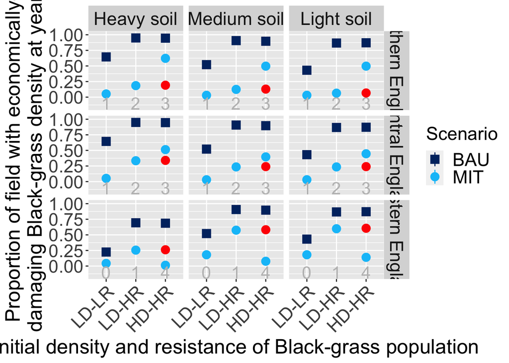

```r
figS3 <- ggplot(prop_hvh %>% dplyr::filter(year == 6 & !scenario=="CWW"), #Keep only yr 6, remove CWW
       aes(initDR, hvh_mean, colour = scenario, shape = scenario)) +
  facet_grid(region ~ soiltype, labeller = labeller(region = region.labs,
                                                    soiltype = soiltype.labs)) +
  scale_x_discrete(guide = guide_axis(angle = 45)) +
  ylim(-0.15, 1) +
  labs(x = "Initial density and resistance of Black-grass population",
       y = "Proportion of field with economically- \ndamaging Black-grass density at year 6") +
  # specify colours and shapes for 'scenario':
  scale_color_manual(name = "Scenario",
                     values = c("#00306F", # BAU, madison blue
                                "#00C2F9")) + # MIT, capri blue
  scale_shape_manual(name = "Scenario",
                     values=c(15, 16)) + # BAU 15 = square; MIT 16 = circle
  theme(strip.placement = 'outside',
        strip.text.x = element_text(size = 18),#, color = "red", face = "bold.italic"
        strip.text.y = element_text(size = 18),
        plot.title = element_text(size=22),
        axis.title=element_text(size=20),
        axis.text.x=element_text(size=rel(2)),
        axis.text.y=element_text(size=rel(2)),
        legend.title=element_text(size=18),
        legend.text=element_text(size=18)
  ) +
  geom_pointrange(aes(ymin = hvh_mean + hvh_sd,
                      ymax = hvh_mean + hvh_sd),
                  size = 0.9
                  ) +
  geom_text(data = anno_den, aes(x = x,  y = y, label = lab),
           colour = "grey",  size=6) +

  # add red point showing LD-HR strategies run with initial very high density
  geom_pointrange(data = prop_hvh_wc %>%
                  dplyr::filter(year == 6 & initDR=="LD-HR" & rotn_seq=="MMM") %>%
                  dplyr::mutate(
                    initDR = recode_factor(initDR, "LD-HR" = "HD-HR")),
                  aes(ymin = hvh_mean + hvh_sd,
                      ymax = hvh_mean + hvh_sd),
                  color = "red",
                  size = 0.9,
                  show.legend = FALSE)

figS3
```

## 4.6. Figure S4 - Mean annual gross profit and wheat yield for each strategy

### 4.6.1. Calculate rotation mean values - current densities

Rotation mean aka annual mean. Only need them for BAU and MIT.

```r
rotn_means <- econ_curr %>%
  dplyr::filter(!scenario == "CWW") %>%
  group_by(scenario, region, soiltype, initDR) %>%
  dplyr::mutate(
    # gross profit
    gp = mean(gpmean),
    gp_min = min(gpmean),
    gp_max = max(gpmean),
    # opportunity costs
    oc = mean(ocmean),
    oc_min = min(ocmean),
    oc_max = max(ocmean),
    # wheat yield
    ww = mean(wwmean),
    ww_min = min(wwmean),
    ww_max = max(wwmean),
    # productivity costs
    pc = mean(pcmean),
    pc_min = min(pcmean),
    pc_max = max(pcmean)
    ) %>%
  # retain only one row per scenario-year:
  distinct(scenario, region, soiltype, initDR, .keep_all = TRUE) %>%
  dplyr::select(scenario, region, soiltype, initDR, gp:pc_max)
```

### 4.6.2. Calculate rotation mean values - worst case densities

Calculate rotation mean for just the first 6 years of the 18 year MMM and BBB sequences. This is then effectively years 1-6 of ‘worst case’ MIT and BAU strategies, and so allows comparison to the estimates obtained for MIT and BAU strategies using current weed densities.

```r
rotn_means_wc <- econ_wc %>%
  dplyr::filter( year %in% c(1:6) & rotn_seq %in% c("MMM", "BBB") ) %>%
  group_by(scenario, region, soiltype, initDR) %>%
  dplyr::mutate(
    # gross profit
    gp = mean(gpmean),
    gp_min = min(gpmean),
    gp_max = max(gpmean),
    # opportunity costs
    oc = mean(ocmean),
    oc_min = min(ocmean),
    oc_max = max(ocmean),
    # wheat yield
    ww = mean(wwmean),
    ww_min = min(wwmean),
    ww_max = max(wwmean),
    # productivity costs
    pc = mean(pcmean),
    pc_min = min(pcmean),
    pc_max = max(pcmean)
    ) %>%
  # retain only one row per scenario-year:
  distinct(scenario, region, soiltype, initDR, .keep_all = TRUE) %>%
  dplyr::select(scenario, region, soiltype, initDR, gp:pc_max)
```

### 4.6.3. Specify Figure S4 and save

Specify panel labels.

```r
region.labs <- c("Northern England", "Central England", "Eastern England") # new
names(region.labs) <- c("n", "c", "e") # original

soiltype.labs <- c("Heavy soil", "Medium soil", "Light soil") # new
names(soiltype.labs) <- c("h", "m", "l") # original
```

Specify the plots.

**Gross profit**

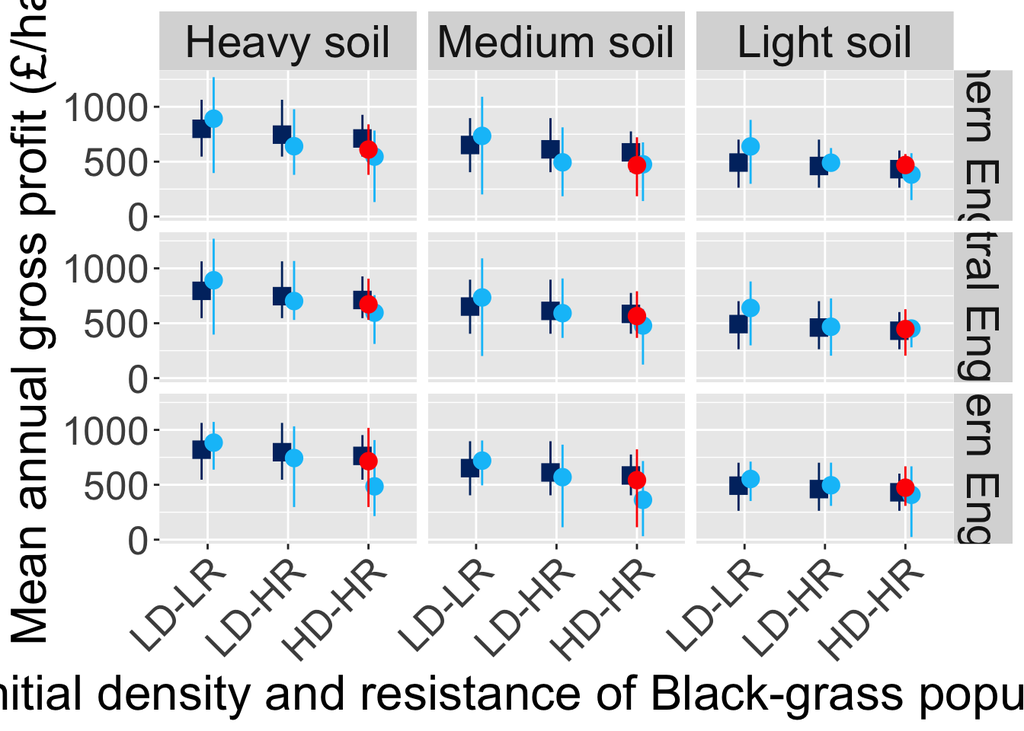

```r
figS4a <- ggplot(rotn_means, aes(initDR, gp, colour = scenario, shape = scenario)) +
  facet_grid(region ~ soiltype,
             labeller = labeller(region = region.labs,
                                 soiltype = soiltype.labs)) +
  scale_x_discrete(guide = guide_axis(angle = 45)) +
  labs(x = "Initial density and resistance of Black-grass population",
       y = "Mean annual gross profit (£/ha)") +
  # specify colours for 'scenario':
  scale_color_manual(name = "Scenario",
                     values = c("#00306F", # BAU, madison blue
                                "#00C2F9", # MIT, capri blue
                                "#005FCC"  # CWW, royal blue
                                )
                     ) +
  scale_shape_manual(name = "Scenario",
                     values=c(15, # BAU, 15 = square
                              16, # MIT, 16 = circle
                              17) # CWW, 17 = triangle
                     ) +
  theme(strip.placement = 'outside',
        strip.text.x = element_text(size = 22),
        strip.text.y = element_text(size = 22),
        axis.title=element_text(size=24),
        axis.text.x=element_text(size=rel(2.2)),
        axis.text.y=element_text(size=rel(2.2))
        ) +
  geom_pointrange(aes(ymin = gp_min, ymax = gp_max),
                  position=position_dodge(width=0.3),
                  size = 0.9) +
  theme(legend.position="none") +
  # add red point showing LD-HR strategies run with initial very high density
  geom_pointrange(data = rotn_means_wc %>%
                  dplyr::filter(initDR=="LD-HR" & scenario=="MIT") %>%
                  dplyr::mutate(initDR = recode_factor(initDR, "LD-HR" = "HD-HR")),
                  aes(ymin = gp_min, ymax = gp_max), color = "red", size = 0.9, show.legend = FALSE)

figS4a
```

**Wheat yield**

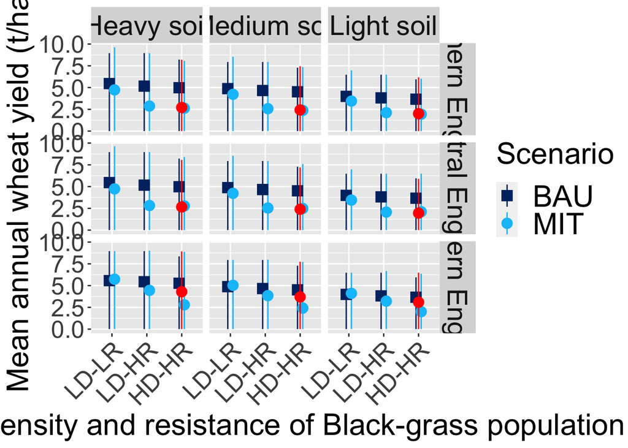

```r
figS4b <- ggplot(rotn_means, aes(initDR, ww, colour = scenario, shape = scenario)) +
  facet_grid(region ~ soiltype,
             labeller = labeller(region = region.labs,
                                 soiltype = soiltype.labs)) +
  scale_x_discrete(guide = guide_axis(angle = 45)) +
  labs(x = "Initial density and resistance of Black-grass population",
       y = "Mean annual wheat yield (t/ha)") +
  # specify colours for 'scenario':
  scale_color_manual(name = "Scenario",
                     values = c("#00306F", # BAU, madison blue
                                "#00C2F9", # MIT, capri blue
                                "#005FCC"  # CWW, royal blue
                                )
                     ) +
  scale_shape_manual(name = "Scenario",
                     values=c(15, # BAU, 15 = square
                              16, # MIT, 16 = circle
                              17) # CWW, 17 = triangle
                     ) +
  theme(strip.placement = 'outside',
        strip.text.x = element_text(size = 22),
        strip.text.y = element_text(size = 22),
        axis.title=element_text(size=24),
        axis.text.x=element_text(size=rel(2.2)),
        axis.text.y=element_text(size=rel(2.2)),
        legend.title=element_text(size=24),
        legend.text=element_text(size=24)
        ) +
  geom_pointrange(aes(ymin = ww_min, ymax = ww_max),
                  position=position_dodge(width=0.3),
                  size = 0.9) +
  # add red point showing LD-HR strategies run with initial very high density
  geom_pointrange(data = rotn_means_wc %>%
                  dplyr::filter(initDR=="LD-HR" & scenario=="MIT") %>%
                  dplyr::mutate(initDR = recode_factor(initDR, "LD-HR" = "HD-HR")),
                  aes(ymin = ww_min, ymax = ww_max), color = "red", size = 0.9, show.legend = FALSE)

figS4b
```

Specify panel plot, save.

```r
figS4 <- (figS4a + figS4b) +
  plot_annotation(tag_levels = 'a', tag_prefix = '(',  tag_suffix = ')') &
  theme(plot.tag = element_text(size = 24, face="bold"))


png("../figures/Figure_S4.png",
    height = 10, width = 20, units = "in", res = 300)
print(figS4)
dev.off()
```